# Omics integraive pipeline: STATegRa

### 2.4.2 miRNA data (`mirna_gbm_corrected`)

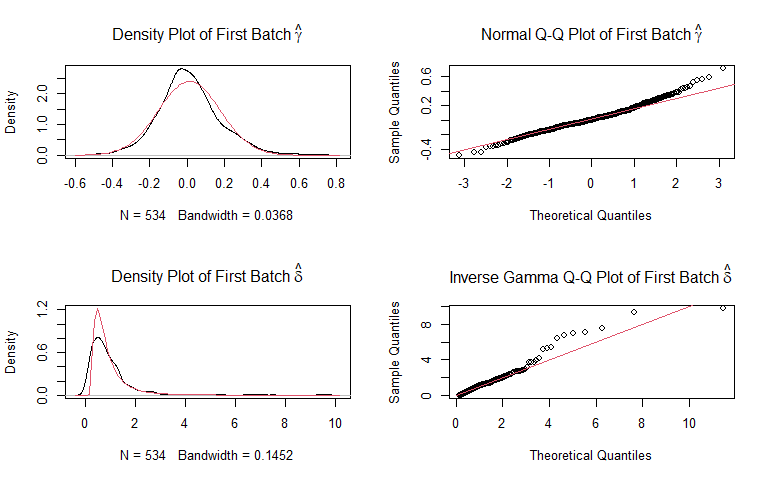

```r
mod <- model.matrix(~gender+GeneExp_Subtype+days_to_birth,
                    data=clinical_gbm[colnames(mirna_gbm_corrected),])

batch <- as.factor(as.character(clinical_gbm[colnames(mirna_gbm_corrected),
                                             'batch_number']))

mirna_gbm_corrected <- ComBat(as.matrix(mirna_gbm_corrected),
                              batch=batch,
                              mod=mod,
                              prior.plot=TRUE)
```

Exploring the PCA from corrected data we can see that the batch effect have been removed. However, in the case of miRNA, the results are equivalent to before batch adjustment, as no batch-effect was detected in the initial data set.

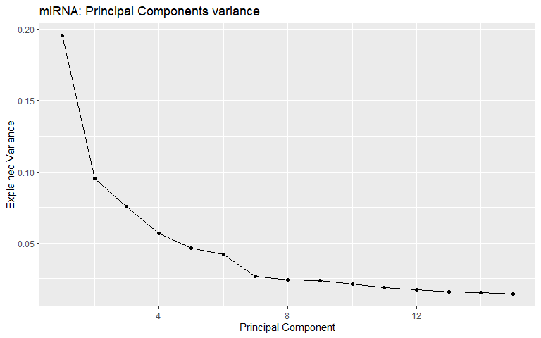

```r
#miRNA
pca_mirna <- prcomp(t(mirna_gbm_corrected))
var_prcomp <- pca_mirna$sdev^2


# Plot PCs variance
pcvar <- data.frame(var=var_prcomp/sum(var_prcomp), pc=c(1:length(var_prcomp)))
ggplot(pcvar[1:15,], aes(x = pc)) + geom_line(aes(y=var)) +
  labs(x='Principal Component', y='Explained Variance') +
  geom_point(aes(y=var)) +
  ggtitle('miRNA: Principal Components variance')
```

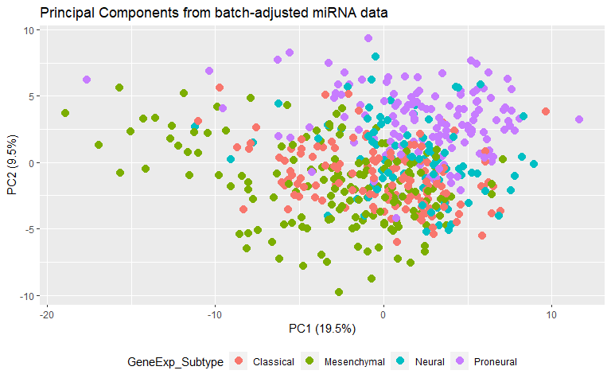

```r
# Plot PCs scores
df <- data.frame(PC1=pca_mirna$x[,1], PC2=pca_mirna$x[,2],
                 clinical_gbm[colnames(mirna_gbm_corrected),
                              c("GeneExp_Subtype","gender","batch_number")])

ggplot(df) +
  geom_point(aes(x=PC1, y=PC2, color=factor(GeneExp_Subtype)),size=5,shape=20) +
  guides(color=guide_legend("GeneExp_Subtype"),
         fill=guide_legend("GeneExp_Subtype")) +
  labs(x='PC1 (19.5%)', y='PC2 (9.5%)') +
  ggtitle("Principal Components from batch-adjusted miRNA data") +
  theme(legend.position="bottom")
```

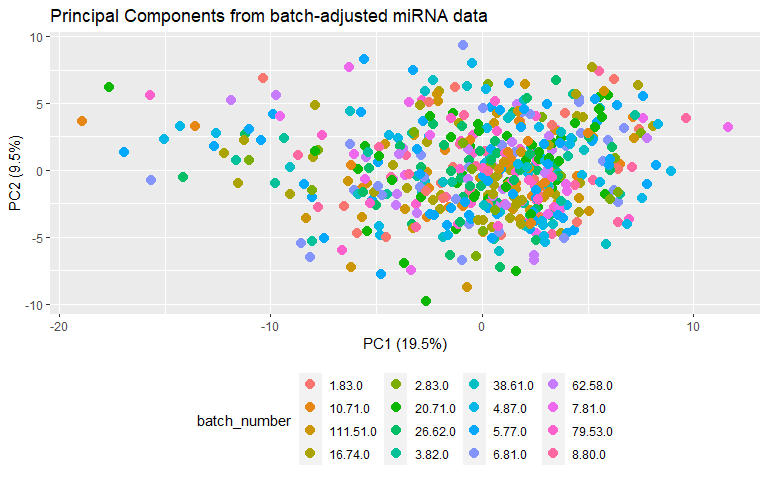

```r
ggplot(df) +
  geom_point(aes(x=PC1, y=PC2, color=factor(batch_number)), size=5, shape=20) +
  guides(color=guide_legend("batch_number"),
         fill=guide_legend("batch_number")) +
  labs(x='PC1 (19.5%)', y='PC2 (9.5%)') +
  ggtitle("Principal Components from batch-adjusted miRNA data") +
  theme(legend.position="bottom")
```

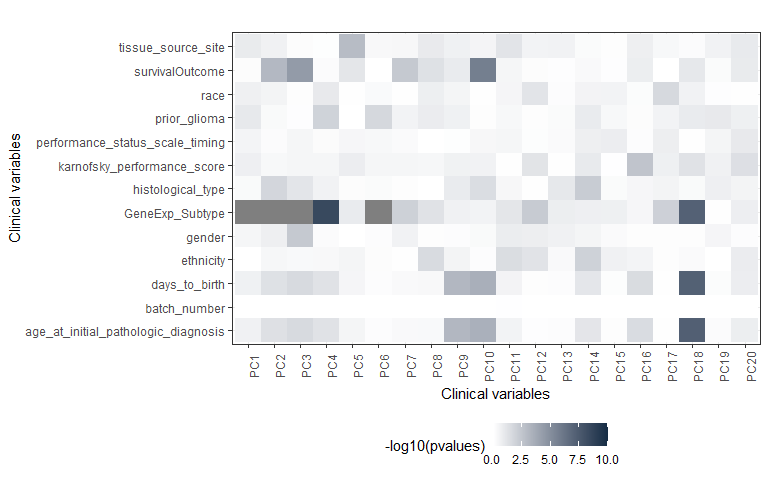

```r
pcaCorrelation(clinical=clinical_gbm[colnames(mirna_gbm_corrected),],
               clin_var=clin_var, pca_data=pca_mirna$x, maxlogPvalue = 10)
```

### 2.4.3 Methylation data (`logit_met_gbm`)

As methylation data not follows a gausian distribution, a non-parametric ComBat is applied.

```r
mod <- model.matrix(~gender+GeneExp_Subtype+days_to_birth,
                    data=clinical_gbm[colnames(logit_met_gbm),])

batch <- as.factor(as.character(clinical_gbm[colnames(logit_met_gbm),
                                             'batch_number']))

logit_met_gbm_corrected <- ComBat(logit_met_gbm,
                                  batch=batch,
                                  mod=mod,
                                  prior.plot=TRUE,
                                  par.prior=FALSE,
                                  BPPARAM=MulticoreParam())
```

Note: the non-parametric ComBat spends long time (>4days with our resources) to compute the corrected matrix.

Exploring the PCA from corrected data we can see that the batch effect have been removed.

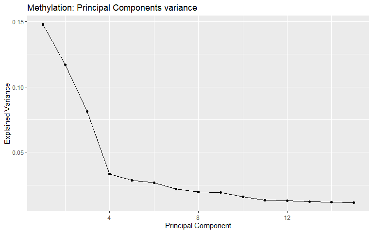

```r
pca_met <- prcomp(t(logit_met_gbm_corrected))
var_prcomp <- pca_met$sdev^2

# Plot PCs variance
pcvar <- data.frame(var=var_prcomp/sum(var_prcomp), pc=c(1:length(var_prcomp)))
ggplot(pcvar[1:15,], aes(x = pc)) + geom_line(aes(y=var)) +
  labs(x='Principal Component', y='Explained Variance') +
  geom_point(aes(y=var)) +
  ggtitle('Methylation: Principal Components variance')
```

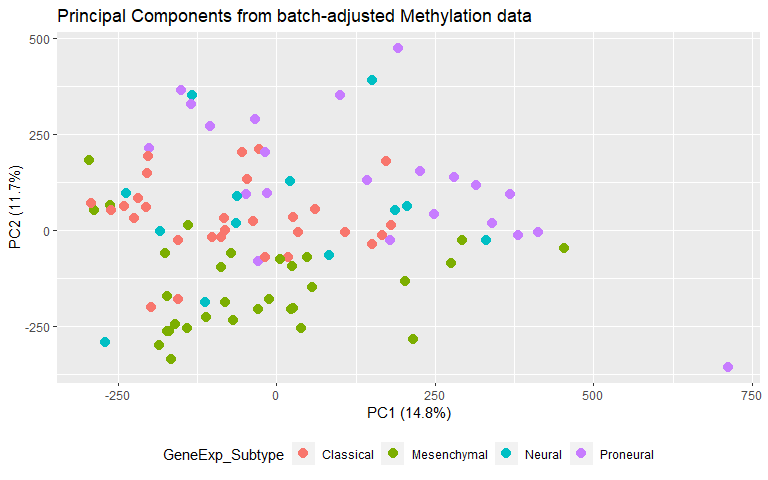

```r
# Plot PCs scores
df <- data.frame(PC1=pca_met$x[,1], PC2=pca_met$x[,2],
                 clinical_gbm[colnames(logit_met_gbm_corrected),
                              c("GeneExp_Subtype","gender","batch_number")])

ggplot(df) +
  geom_point(aes(x=PC1, y=PC2,color=factor(GeneExp_Subtype)),size=5,shape=20) +
  guides(color=guide_legend("GeneExp_Subtype"),
         fill=guide_legend("GeneExp_Subtype")) +
  labs(x='PC1 (14.8%)', y='PC2 (11.7%)') +
  ggtitle("Principal Components from batch-adjusted Methylation data") +
  theme(legend.position="bottom")
```

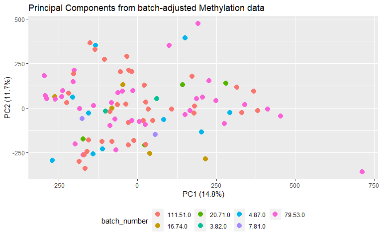

```r
ggplot(df) +
  geom_point(aes(x=PC1, y=PC2, color=factor(batch_number)), size=5, shape=20) +
  guides(color=guide_legend("batch_number"),
         fill=guide_legend("batch_number")) +
  labs(x='PC1 (14.8%)', y='PC2 (11.7%)') +
  ggtitle("Principal Components from batch-adjusted Methylation data") +
  theme(legend.position="bottom")
```

Now, the association analysis shows how the batch effect is clearly removed from our data and the main variability is related with gene expression subtype and survival outcome.

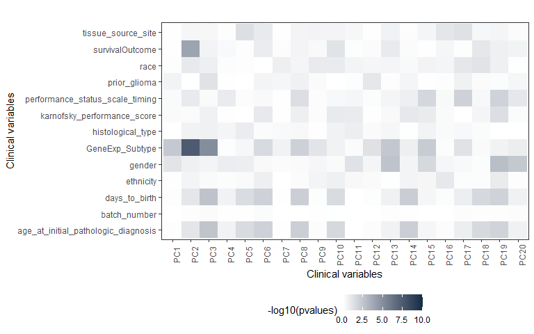

```r
pcaCorrelation(clinical=clinical_gbm[colnames(logit_met_gbm_corrected),],
               clin_var=clin_var, pca_data=pca_met$x, maxlogPvalue = 10)
```

## 2.5 Characterization of the data: Individual exploration

After data pre-process we are ready to work with the different omics. Batch effect has been corrected in each data-type and the appropiate transformation has been applied according the data-type.

As seen in the previous exploration after batch correction (see previous section), the graphical representation of explained variance for the first fifteen components show that variance explained for the first components is not quite high, moving between 10 and 20%. This fact highlights the data heterogeneity and the missing of a driving variable explaining the most variability of our data. As expected, high association with the gene expression subtypes, previously defined, is found with the first PCs of mRNA, but also in miRNA and methylation. Relevant variables associated with first components are survival outcome, histological type, prior glioma, age and gender.

## 2.6 Characterization of the data: Joint exploration

### 2.6.1 Common samples

As we have different number of samples in each omic dataset, we need to determine the share samples between omics.

```r
# Load require packages
library(VennDiagram)
library(plotrix)
```

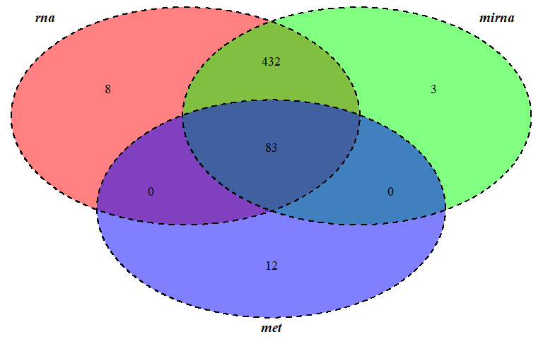

```r
# Venn Diagram
m <- list(rna=colnames(rna_gbm_corrected),
          mirna=colnames(mirna_gbm_corrected),
          met=colnames(logit_met_gbm_corrected))

vennPlot <- venn.diagram(m, NULL, fill=c('red','green','blue'),
                         cat.fontface=4, lty=2, cex=1.2, cat.cex=1.2)
grid.newpage()
grid.draw(vennPlot)
```

We have 515 samples (almost 100%) with both mRNA and miRNA data, however, just 83 samples have mRNA, miRNA and methylation data.

### 2.6.2 OmicsPCA exploration

Based on first data exploration and pre-process, we know that the most rellevant variables in our omics data-types after batch correction are gene expression subtype, survival outcome and age.

But, how much the different data-types are “explaining the samples in the same way”? To be more specific: are there share components or not? How many?

Let’s perform a joint exploration using the `omicsCompAnalysis` function from `STATegRa` package.

```r
# Load require packages
library(STATegRa)
library(MASS)
library(gridExtra)
```

#### 2.6.2.1 Data scaling

Before start the multi-omic approach, mean centred of each feature and the data set normalization to unit sum of squares (forbenious normalization) is recommended to make more comparabable the different omics data-sets.

```r
#Calculate Forbenious normalization
frobenius_rna <- norm(as.matrix(rna_gbm_corrected), type="F")
frobenius_mirna <- norm(as.matrix(mirna_gbm_corrected), type="F")
frobenius_met <- norm(as.matrix(logit_met_gbm_corrected), type="F")

#Mean-centring and division by Frobenius normalization factor
rna_gbm_norm <- t(scale(t(rna_gbm_corrected), scale=FALSE))/frobenius_rna
mirna_gbm_norm <- t(scale(t(mirna_gbm_corrected), scale=FALSE))/frobenius_mirna
met_gbm_norm <- t(scale(t(logit_met_gbm_corrected), scale=FALSE))/frobenius_met

##Mean-centring without Frobenius normalization
rna_gbm_norm2 <- t(scale(t(rna_gbm_corrected), scale=FALSE))
mirna_gbm_norm2 <- t(scale(t(mirna_gbm_corrected), scale=FALSE))
met_gbm_norm2 <- t(scale(t(logit_met_gbm_corrected), scale=FALSE))
```

Then, we need to keep the common samples between the different data sets.

```r
#Common samples between mRNA and miRNA
ids_rna_mirna <- intersect(colnames(rna_gbm_corrected), colnames(mirna_gbm_corrected))
length(ids_rna_mirna)
```

```
## [1] 515
```

```r
#Common samples between mRNA and Methylation
ids_rna_met <- intersect(colnames(rna_gbm_corrected), colnames(logit_met_gbm_corrected))
length(ids_rna_met)
```

```
## [1] 83
```

#### 2.6.2.2 Model selection

Now, we are ready to explore if there are share components between data-types.

The first step is to determine the number of share/common and individual components between omics.

How to determine these numbers is still an open question nowadays, so the user can explore different methods like jive, pca-gca and pESCA, between others. Following, we show how to perform the model selection based on these three methods.

##### 2.6.2.2.1 JIVE

```r
# Load require packages
library(r.jive)
```

```r
#Using r.jive

################################################
## mRNA + miRNA (already centered)            ##
################################################
Data <- list(mRNA=rna_gbm_norm[,ids_rna_mirna],
             miRNA=mirna_gbm_norm[,ids_rna_mirna])
rjive_rna_mirna <- jive(Data, scale = FALSE, center = FALSE)


######################################################
## mRNA + methylation (already centered)            ##
######################################################
Data <- list(mRNA=rna_gbm_norm[,ids_rna_met],
              met=met_gbm_norm[,ids_rna_met])
rjive_rna_met <- jive(Data, scale = FALSE, center = FALSE)
```

##### 2.6.2.2.2 PCA-GCA

```r
# Load require packages
library(RegularizedSCA)

#Using pca-gca

################################################
## mRNA + miRNA (already centered and scaled) ##
################################################
data <- cbind(t(rna_gbm_norm[,ids_rna_mirna]),
              t(mirna_gbm_norm[,ids_rna_mirna]))

# Number of variables
Jk <- c(nrow(rna_gbm_norm), nrow(mirna_gbm_norm))

# Select components
pca_gca(data, Jk, cor_min = .7)

######################################################
## mRNA + methylation (already centered and scaled) ##
######################################################
data <- cbind(t(rna_gbm_norm[,ids_rna_met]),
              t(met_gbm_norm[,ids_rna_met]))

# Number of variables
Jk <- c(nrow(rna_gbm_norm), nrow(met_gbm_norm))

# Select components
pca_gca(data, Jk, cor_min = .7)
```

##### 2.6.2.2.3 pESCA

```r
# Load require packages
library(RpESCA)
library(RSpectra)

#Using RpESCA

################################################
## mRNA + miRNA (already centered)            ##
################################################

dataSets <- list(rna=t(rna_gbm_norm2[,ids_rna_mirna]),
                 mirna=t(mirna_gbm_norm2[,ids_rna_mirna]))

dataTypes <- 'GG'

# used parameters
opts <- list()
opts$tol_obj <- 1E-4
opts$quiet <- 1

# save the estimated alphas, selected number of PCs and cvErrors
alphas <- rep(NA,2)
R_selected_list <- as.list(1:2)
cvErrors_list <- as.list(1:2)

# alpha estimation for each data set
for (i in 1:length(dataSets)){
  # index ith data set
  X <- dataSets[[i]]

  # alpha estimation procedure
  alpha_est <- alpha_estimation(X,K=3,Rs = 5:20,opts=opts)
  alphas[i] <- alpha_est$alphas_mean
  R_selected_list[[i]] <- alpha_est$R_CV
  cvErrors_list[[i]] <- alpha_est$cvErrors
}
names(alphas) <- paste0('alpha', 1:2)

## Setting the parameters for the pESCA model

# concave function and its hyper-parameter
fun_concave <- 'gdp'; gamma <- 1;
penalty = 'L2' # concave L2 norm penalty

# Parameters of a pESCA with concave L2norm penalty model
opts <- list()
opts$gamma <- gamma  # hyper-parameter for the used penalty
opts$rand_start <- 0
opts$tol_obj <- 1e-6 # stopping criteria
opts$maxit   <- 500
opts$alphas  <- alphas
#opts$R  # components used Default 0.5*min(I,J) - Minimum number of variables.
opts$thr_path <- 0 # generaint thresholding path or not
opts$quiet <- 1

# Model selection pESCA conave L2 norm penalty
nTries <- 15
lambdas_CV <- log10_seq(from=1, to=500, length.out=nTries)

result_CV <- pESCA_CV(dataSets, dataTypes,
                      lambdas_CV,
                      penalty=penalty,
                      fun_concave=fun_concave,
                      opts=opts)


# select the model with minimum CV error
index_min_cv <- which.min(result_CV$cvErrors_mat[,1])

# cvErrors during the model selection process
result_CV$cvErrors_mat

# selected value of lambda
lambdas_CV[index_min_cv]

# fit the final model
lambdas_opt <- rep(lambdas_CV[index_min_cv],length(dataSets))
opts_opt <- result_CV$inits[[index_min_cv]]
opts_opt$tol_obj <- 1E-8 # using high precision model


pESCA_L2 <- pESCA(dataSets = dataSets,
                          dataTypes = dataTypes,
                          lambdas = lambdas_opt,
                          penalty = penalty,
                          fun_concave= fun_concave,
                          opts = opts_opt)


mu <- pESCA_L2$mu
A <- pESCA_L2$A
B <- pESCA_L2$B
S <- pESCA_L2$S

# estimated variation explained ratios for each data set or the full data set
pESCA_L2$varExpTotals

# estimated variation explained ratios of each PC for each data set or the full data set
pESCA_L2$varExpPCs

#Cut-off 1%
sel1 <- which(pESCA_L2$varExpPCs[1,]>1) #13
sel2 <- which(pESCA_L2$varExpPCs[2,]>1) #21
intersect(sel1,sel2)
# 7 common components
# 6 dist mRNA + 14 miRNA
# Total: 27 components

# Cut-off 5%
sel1 <- which(pESCA_L2$varExpPCs[1,]>5) #5
sel2 <- which(pESCA_L2$varExpPCs[2,]>5) #2
intersect(sel1,sel2)
# 1 common components
# 4 dist mRNA + 1 miRNA
# Total: 6 components


################################################
## mRNA + Methylation (already centered)      ##
################################################

dataSets <- list(rna=t(rna_gbm_norm2[,ids_rna_met]),
                 met=t(met_gbm_norm2[,ids_rna_met]))

dataTypes <- 'GG'

# used parameters
opts <- list()
opts$tol_obj <- 1E-4
opts$quiet <- 1

# save the estimated alphas, selected number of PCs and cvErrors
alphas <- rep(NA,2)
R_selected_list <- as.list(1:2)
cvErrors_list <- as.list(1:2)

# alpha estimation for each data set
for (i in 1:length(dataSets)){
  # index ith data set
  X <- dataSets[[i]]

  # alpha estimation procedure
  alpha_est <- alpha_estimation(X,K=3,Rs = 5:20,opts=opts)
  alphas[i] <- alpha_est$alphas_mean
  R_selected_list[[i]] <- alpha_est$R_CV
  cvErrors_list[[i]] <- alpha_est$cvErrors
}
names(alphas) <- paste0('alpha', 1:2)

## Setting the parameters for the pESCA model

# concave function and its hyper-parameter
fun_concave <- 'gdp'; gamma <- 1;
penalty = 'L2' # concave L2 norm penalty

# Parameters of a pESCA with concave L2norm penalty model
opts <- list()
opts$gamma <- gamma  # hyper-parameter for the used penalty
opts$rand_start <- 0
opts$tol_obj <- 1e-6 # stopping criteria
opts$maxit   <- 500
opts$alphas  <- alphas
#opts$R # components used Default 0.5*min(I,J) - Minimum number of variables.
opts$thr_path <- 0 # generaint thresholding path or not
opts$quiet <- 1

# Model selection pESCA conave L2 norm penalty
nTries <- 15
lambdas_CV <- log10_seq(from=1, to=500, length.out=nTries)

result_CV <- pESCA_CV(dataSets, dataTypes,
                      lambdas_CV,
                      penalty=penalty,
                      fun_concave=fun_concave,
                      opts=opts)


# select the model with minimum CV error
index_min_cv <- which.min(result_CV$cvErrors_mat[,1])

# cvErrors during the model selection process
result_CV$cvErrors_mat

# selected value of lambda
lambdas_CV[index_min_cv]

# fit the final model
lambdas_opt <- rep(lambdas_CV[index_min_cv],length(dataSets))
opts_opt <- result_CV$inits[[index_min_cv]]
opts_opt$tol_obj <- 1E-8 # using high precision model


pESCA_L2 <- pESCA(dataSets = dataSets,
                          dataTypes = dataTypes,
                          lambdas = lambdas_opt,
                          penalty = penalty,
                          fun_concave= fun_concave,
                          opts = opts_opt)

mu <- pESCA_L2$mu
A <- pESCA_L2$A
B <- pESCA_L2$B
S <- pESCA_L2$S

# estimated variation explained ratios for each data set or the full data set
pESCA_L2$varExpTotals

# estimated variation explained ratios of each PC for each data set or the full data set
pESCA_L2$varExpPCs

#Cut-off 1%
sel1 <- which(pESCA_L2$varExpPCs[1,]>1) #2
sel2 <- which(pESCA_L2$varExpPCs[2,]>1) #9
intersect(sel1,sel2)
# 1 common components
# 1 dist mRNA + 8 methylation
# Total: 10 components

#Cut-off 5%
sel1 <- which(pESCA_L2$varExpPCs[1,]>5) #2
sel2 <- which(pESCA_L2$varExpPCs[2,]>5) #3
intersect(sel1,sel2)
# 1 common components
# 1 dist mRNA + 2 methylation
# Total: 4 components
```

Here, there is the table summarizing the output of the different methods.

|  | Component | r.JIVE | PCA-GCA (1%) | PCA-GCA (5%) | pESCA(1%) | pESCA (5%) |
| --- | --- | --- | --- | --- | --- | --- |
| mRNA + miRNA |  |  |  |  |  |  |
|  | Common | 1 | 3 | NA | 7 | 1 |
|  | Dist. mRNA | 50 | 8 | NA | 6 | 4 |
|  | Dist. miRNA | 19 | 5 | NA | 14 | 1 |
| mRNA + met |  |  |  |  |  |  |
|  | Common | 3 | NA | NA | 1 | 1 |
|  | Dist. mRNA | 17 | NA | NA | 1 | 1 |
|  | Dist. miRNA | 25 | NA | NA | 8 | 2 |

Again, we can observe that the results from different methods have relevant divergencies. Mainly, we can say that share variation between data is not too large, but it seems that there’s something explained in the same way. To follow with the analysis, we will explore the omicsPCA based on the output of pESCA (1%).

#### 2.6.2.3 Sub-space recovery

Based on the number of components identified (pESCA) we can recover the subspace.

It is interesting to take a look on the common and distinctive components identified thorugh this method.

```r
################################################
## mRNA + miRNA (already centered)            ##
################################################

# Explore the common and distinctive components and those variation explained
# Common components
cc <- intersect(sel1,sel2)
pESCA_L2$varExpPCs[,cc]
```

```
##             PC1      PC3      PC4      PC6      PC7      PC9     PC11
## X_1    12.31097 6.648208 5.547511 2.958637 2.419148 1.833125 1.282475
## X_2    10.02265 4.273318 3.941567 1.445866 3.060845 1.418305 1.353780
## X_full 12.16291 6.494543 5.443599 2.860755 2.460668 1.806284 1.287089
```

```r
# Distinctive components
dist_rna <- sel1[!sel1%in%cc] #rna
pESCA_L2$varExpPCs[,dist_rna]
```

```
##              PC2       PC5       PC8      PC10     PC12     PC13
## X_1    8.0683705 5.3879052 2.0484025 1.4743292 1.195001 1.091788
## X_2    0.5333225 0.3595895 0.6113683 0.8597992 0.000000 0.000000
## X_full 7.5808210 5.0625519 1.9554203 1.4345665 1.117680 1.021145
```

```r
dist_mirna <- sel2[!sel2%in%cc] #mirna
pESCA_L2$varExpPCs[,dist_mirna]
```

```
##             PC17      PC19       PC25      PC43      PC69      PC74     PC113
## X_1    0.6366036 0.6955921  0.0000000 0.2801706 0.1707055 0.2450968 0.0000000
## X_2    2.0762611 1.3458879 11.3074793 4.6778476 1.0128559 1.3851853 2.4789441
## X_full 0.7297555 0.7376690  0.7316418 0.5647189 0.2251962 0.3188653 0.1603982
##             PC118     PC129     PC130     PC134     PC136      PC139      PC147
## X_1    0.00000000 0.0000000 0.0000000 0.0000000 0.0000000 0.00000000 0.00000000
## X_2    1.17557417 2.1242175 3.1881778 1.6015304 1.6993565 1.27223736 1.16930411
## X_full 0.07606463 0.1374459 0.2062886 0.1036258 0.1099556 0.08231915 0.07565893
```

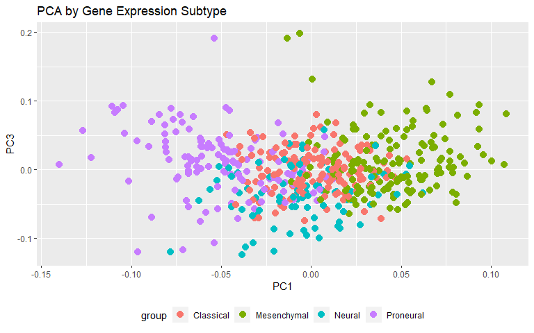

```r
# Keep de common and distinctive components
common_pc <- pESCA_L2$A[,cc]
colnames(common_pc) <- colnames(pESCA_L2$varExpPCs[,cc])

dist_rna_pc <- pESCA_L2$A[,dist_rna]
colnames(dist_rna_pc) <- names(dist_rna)

dist_mirna_pc <- pESCA_L2$A[,dist_mirna]
colnames(dist_mirna_pc) <- names(dist_mirna)


# metadata for common samples
clin <- clinical_gbm[ids_rna_mirna,]

# PCA plot
require(ggplot2)

df <- as.data.frame(common_pc)
df$group <- clin$GeneExp_Subtype
df$batch <- clin$batch_number

#plot of first common components by gene expression subtype
p <- ggplot(df,aes_string("PC1","PC3",color="group"))
p + geom_point(size=5, shape=20) + ggtitle("PCA by Gene Expression Subtype") + theme(legend.position="bottom")
```

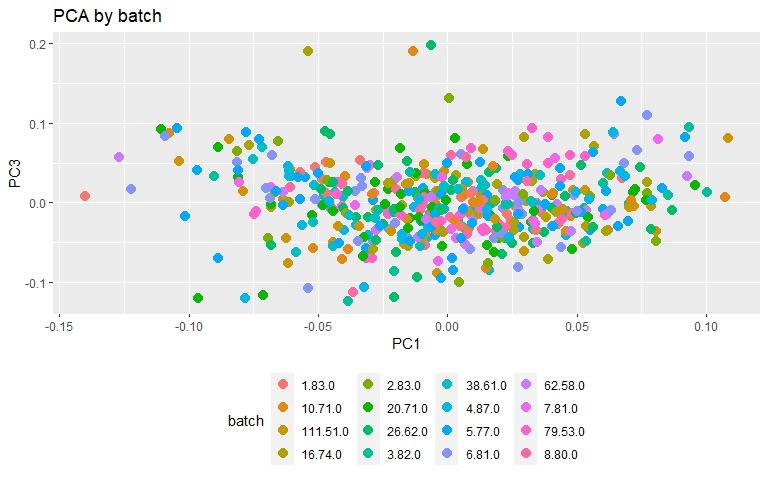

```r
#plot of first common components by batch
p <- ggplot(df,aes_string("PC1","PC3",color="batch"))
p + geom_point(size=5, shape=20) + ggtitle("PCA by batch") + theme(legend.position="bottom")
```

Let’s explore how relate these common and distinctive components with the clinical variables.

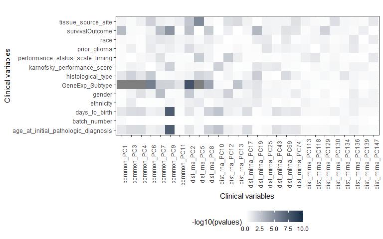

```r
df <- data.frame(common_pc,dist_rna_pc,dist_mirna_pc)
colnames(df) <- c(paste("common_",colnames(common_pc),sep=""),
                  paste("dist_rna_",colnames(dist_rna_pc),sep=""),
                  paste("dist_mirna_",colnames(dist_mirna_pc),sep=""))

pcaCorrelation(clinical=clin, clin_var, df, maxlogPvalue =10, maxPC=ncol(df), pc.names=TRUE)
```

The main common variability for mRNA + miRNA is associated with `GeneExp_Subtype`, `survivalOutcome`, `days_to_birth` and `age_at_initial_pathologic_diagnosis`. No batch effect is identified. Moreover, the main variability explained by mRNA distinctive components are associated with `GeneExp_Subtype`, too.

```r
################################################
## mRNA + methylation (already centered)      ##
################################################

# Explore the common and distinctive components and those variation explained
# Common components
cc <- intersect(sel1,sel2)
pESCA_L2$varExpPCs[,cc]
```

```
##       X_1       X_2    X_full
##  8.126533 11.062577 10.928992
```

```r
# Distinctive components
dist_rna <- sel1[!sel1%in%cc] #rna
pESCA_L2$varExpPCs[,dist_rna]
```

```
##       X_1       X_2    X_full
## 12.012788  0.000000  0.546561
```

```r
dist_met <- sel2[!sel2%in%cc] #met
pESCA_L2$varExpPCs[,dist_met]
```

```
##             PC1      PC3      PC4      PC5      PC6      PC7      PC8      PC9
## X_1     0.00000 0.000000 0.000000 0.000000 0.000000 0.000000 0.000000 0.000000
## X_2    14.81974 8.101900 3.433565 2.998602 2.848740 2.132701 1.956806 1.764833
## X_full 14.14547 7.733277 3.277344 2.862171 2.719128 2.035667 1.867774 1.684536
```

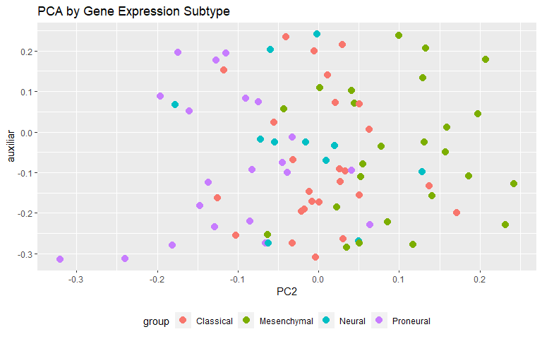

```r
# Keep de common and distinctive components
common_pc <- data.frame(pESCA_L2$A[,cc])
colnames(common_pc) <- paste("PC", cc, sep="")

dist_rna_pc <- data.frame(pESCA_L2$A[,dist_rna])
colnames(dist_rna_pc) <- names(dist_rna)

dist_met_pc <- pESCA_L2$A[,dist_met]
colnames(dist_met_pc) <- names(dist_met)


# metadata for common samples
clin <- clinical_gbm[ids_rna_met,]

# PCA plot
require(ggplot2)

df <- as.data.frame(common_pc)
df$group <- clin$GeneExp_Subtype
df$batch <- clin$batch_number

# As only one common component is found, an auxiliar varaible is defined in order to visualize the first components.
df$auxiliar <- runif(nrow(df),min(df$PC2, na.rm=TRUE),max(df$PC2, na.rm=TRUE))

#plot of first common components by gene expression subtype
p <- ggplot(df,aes_string("PC2","auxiliar",color="group"))
p + geom_point(size=5, shape=20) + ggtitle("PCA by Gene Expression Subtype") + theme(legend.position="bottom")
```

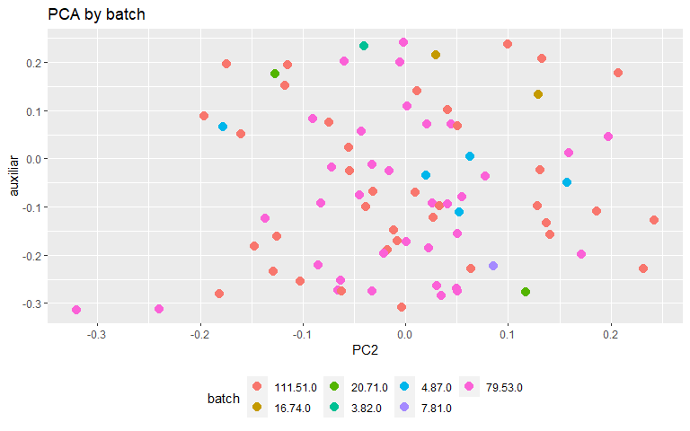

```r
#plot of first common components by batch
p <- ggplot(df,aes_string("PC2","auxiliar",color="batch"))
p + geom_point(size=5, shape=20) + ggtitle("PCA by batch") + theme(legend.position="bottom")
```

Let’s explore how relate these common and distinctive components with the clinical variables.

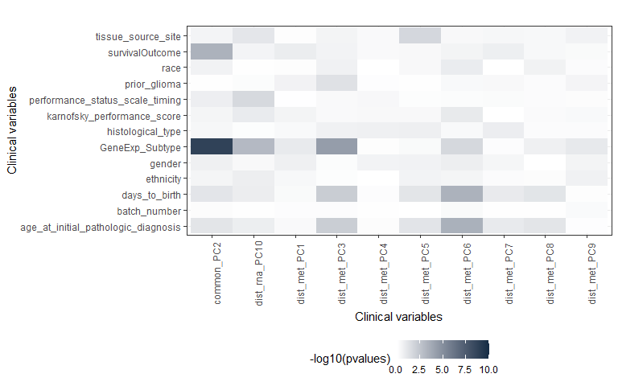

```r
df <- data.frame(common_pc,dist_rna_pc,dist_met_pc)
colnames(df) <- c(paste("common_",colnames(common_pc),sep=""),
                  paste("dist_rna_",colnames(dist_rna_pc),sep=""),
                  paste("dist_met_",colnames(dist_met_pc),sep=""))

pcaCorrelation(clinical=clin, clin_var, df, maxlogPvalue =10, maxPC=ncol(df), pc.names=TRUE)
```

Again, the main common variability for mRNA + methylation is associated with `GeneExp_Subtype` and `survivalOutcome`. Moreover, distinctive components for methylation are associated with `days_to_birth` and `age_at_initial_pathologic_diagnosis`.

## 2.7 Integrative differential analysis by NPC

Now, we want to identify genes that, according to all modalities considered as a whole (mRNA, miRNA, methylation, etc.), are either deregulated or associated to an outcome of interest.

From the previous steps (individual omics exploration and joint exploration) we will be considering (1) which co-variates are necessary to include and (2) which analysis do we want to perform.

Let’s explore the combination of two omics, then NPC will provide two outcomes:

- The features that are differentiated in both omics, therefore we are looking into coordinated effects.
- The features that are differentiated in only one of the omics.

These kind of approach allows different number of samples between omics, so we will explore both escenarios.

### 2.7.1 mRNA + miRNA

First of all we need to have a mapping file mathcing omics.

#### 2.7.1.1 Mapping file

```r
#Load the mapping info
#load('hsa-vtm-gene.Rdata')
#the mapping can be obtained using SpidermiR package

#Identify the miRBase version of mapping file and data
library(miRNAmeConverter)

miRNAs <- rownames(mirna_gbm_corrected)
miRNAs_mapping <- names(id)
nc <- MiRNANameConverter()
assessVersion(nc, miRNAs, verbose = FALSE) #version 9.2
```

```
##    version frequency
## 1      9.2       534
## 2      9.1       534
## 3      9.0       533
## 4      8.2       516
## 5      8.1       515
## 6     10.0       430
## 7     10.1       424
## 8     11.0       422
## 9     14.0       420
## 10    13.0       420
## 11    12.0       420
## 12    15.0       419
## 13    16.0       416
## 14    17.0       415
## 15     8.0       360
## 16     7.1       340
## 17    18.0       245
## 18    19.0       218
## 19     6.0       208
## 20    20.0       174
## 21    21.0       173
## 22    22.0       165
```

```r
assessVersion(nc, miRNAs_mapping, verbose = FALSE) #version 20
```

```
##    version frequency
## 1     20.0       573
## 2     21.0       569
## 3     22.0       560
## 4     19.0       546
## 5     18.0       533
## 6     17.0       380
## 7     16.0       372
## 8     15.0       359
## 9     14.0       341
## 10    13.0       339
## 11    12.0       338
## 12    11.0       337
## 13    10.1       321
## 14    10.0       314
## 15     9.2       228
## 16     9.1       228
## 17     9.0       227
## 18     8.2       220
## 19     8.1       220
## 20     8.0       181
## 21     7.1       178
## 22     6.0       145
```

```r
#convert miRNA annotation from our miRNA matrix from v.9.2 to v.20
library(anamiR)
new_mirna_matrix <- miR_converter(mirna_gbm_corrected, remove_old = TRUE, original_version=9.2, latest_version = 20)
#Original data 534 miRNAs, now 527 miRNAs


#restricting mapping info to measured miRNA
id_mapping <- id[intersect(names(id), rownames(new_mirna_matrix))]
#from the initial 527 miRNA features we get 332 miRNA shared with mapping info

#creating the miRNA association tables
mirna2GeneMap <- stack(id_mapping) #convert in a data.frame. Each line has a gene and one mirna.
names(mirna2GeneMap) <- c('Gene', 'miRNA')
#Dimension: 33324 x 2 (33,324 pairs)

head(mirna2GeneMap)
```

```
##     Gene         miRNA
## 1  ACAD8 hsa-let-7a-5p
## 2   ACTB hsa-let-7a-5p
## 3 ACVR1B hsa-let-7a-5p
## 4   ADSL hsa-let-7a-5p
## 5   AGO1 hsa-let-7a-5p
## 6   AGO2 hsa-let-7a-5p
```

```r
#creating the mRNA association tables
expr2GeneMap <- data.frame(measurement = rownames(rna_gbm_corrected),
                           Gene = rownames(rna_gbm_corrected))
#Dimension: 12,042 x 2

head(expr2GeneMap)
```

```
##   measurement    Gene
## 1       FSTL1   FSTL1
## 2        AACS    AACS
## 3       RPS11   RPS11
## 4     CREB3L1 CREB3L1
## 5       ELMO2   ELMO2
## 6       PNMA1   PNMA1
```

```r
#creating the data mapping
dataMappingExprMirna <- combiningMappings(mappings = list(expr = expr2GeneMap,
                                                          mirna = mirna2GeneMap),
                                          retainAll = TRUE, reference = 'Gene');
#Dimension: 24,665 x 3

head(dataMappingExprMirna)
```

```
##      expr           mirna   Gene
## 4     A2M  hsa-miR-122-5p    A2M
## 5     A2M   hsa-miR-98-5p    A2M
## 6     A2M  hsa-miR-128-3p    A2M
## 7  A4GALT hsa-miR-193b-3p A4GALT
## 9    AAAS   hsa-miR-16-5p   AAAS
## 10   AAAS hsa-miR-193b-3p   AAAS
```

We can see that based on our mRNA and miRNA analysis, we have 24,665 pairs in total, it corresponds to 7,814 unique genes (64.9% from the whole mRNA dataset) and 323 unique miRNAs (61.3% from teh whole miRNA dataset).

Then, we define the relevant clinical variables in each scenario. Our variable of interest in the case of GBM is the `survivalOtucome`. Moreover, `days_to_birth` is included as a confounder.

```r
clinicalVariables <- list(expr = c('days_to_birth', 'survivalOutcome'),
                          met = c('days_to_birth', 'survivalOutcome'),
                          mirna = c('days_to_birth', 'survivalOutcome'));
```

Then, we can explore the combination of these two omics using a parametric or non parametric combination (PC or NPC). Moreover, we can perform the analysis on all available samples or just for those that are common between datasets. So, these are the different scenarios that we can have:

- Overlapping samples
  - Parametric Combination of p-values (`omicsPC`)
  - Non Parametric Combination of p-values (`omicsNPC`)
- All samples
  - Parametric Combination of p-values (`omicsPC`)
  - Non Parametric Combination of p-values (`omicsNPC`)

As first approach, we will start to explore the combination just for the overlapping samples, followed by the all samples approach.

#### 2.7.1.2 Overlaping samples

```r
#restrict the datasets to the elements of the data mapping and those samples that are common between omics
exprTMP <- rna_gbm_corrected[unique(na.omit(dataMappingExprMirna$expr)), ids_rna_mirna]; #7,814 x 515

mirnaTMP <- new_mirna_matrix[unique(na.omit(dataMappingExprMirna$mirna)), ids_rna_mirna]; #323 x 515

#specifying the data types.
dataTypesExprMirna <- list(ttCoxphContinuous,ttCoxphContinuous)

#preparing the datasets
exprTMP <- createOmicsExpressionSet(Data = as.matrix(exprTMP),
                                    pData = clinical_gbm[ids_rna_mirna,clinicalVariables[['expr']]])
names(pData(exprTMP)) <- c("age","outcome")

mirnaTMP <- createOmicsExpressionSet(Data = as.matrix(mirnaTMP),
                                     pData = clinical_gbm[ids_rna_mirna,clinicalVariables[['mirna']]])
names(pData(mirnaTMP)) <- c("age","outcome")

dataInputExprMirna <- list(expr = exprTMP, mirna = mirnaTMP)
```

##### 2.7.1.2.1 Parametric Combination

```r
set.seed(12345)
omicsPCRes_cPC <- omicsPC(dataInput = dataInputExprMirna,
                       dataMapping = dataMappingExprMirna,
                       dataTypes = dataTypesExprMirna,
                       verbose = TRUE)
```

The output of `omicsPC` provides information regarding p-value and adjusted p-value from both individual and combined analysis.

```r
res <- omicsPCRes_cPC
str(res)
```

```
## List of 4
##  $ expr     : num [1:7814, 1:6] 0.1343 -0.2055 -0.0694 0.2895 0.0531 ...
##   ..- attr(*, "dimnames")=List of 2
##   .. ..$ : chr [1:7814] "A2M" "A4GALT" "AAAS" "AACS" ...
##   .. ..$ : chr [1:6] "coef" "exp(coef)" "se(coef)" "z" ...
##  $ mirna    : num [1:323, 1:6] 1.0453 -0.0639 -0.0494 0.0683 -0.0126 ...
##   ..- attr(*, "dimnames")=List of 2
##   .. ..$ : chr [1:323] "hsa-miR-122-5p" "hsa-miR-98-5p" "hsa-miR-128-3p" "hsa-miR-193b-3p" ...
##   .. ..$ : chr [1:6] "coef" "exp(coef)" "se(coef)" "z" ...
##  $ pvaluesPC:'data.frame':   24665 obs. of  8 variables:
##   ..$ expr     : chr [1:24665] "A2M" "A2M" "A2M" "A4GALT" ...
##   ..$ mirna    : chr [1:24665] "hsa-miR-122-5p" "hsa-miR-98-5p" "hsa-miR-128-3p" "hsa-miR-193b-3p" ...
##   ..$ Fisher   : num [1:24665] 0.022 0.0457 0.0495 0.4351 0.8912 ...
##   ..$ Liptak   : num [1:24665] 0.0179 0.0626 0.0743 0.3432 0.8693 ...
##   ..$ Tippett  : num [1:24665] 0.0317 0.0317 0.0317 0.775 1 ...
##   ..$ Benjamini: num [1:24665] 0.0317 0.0317 0.0317 0.3878 0.8893 ...
##   ..$ Simes    : num [1:24665] 0.0317 0.0317 0.0317 0.3878 0.8893 ...
##   ..$ Sidak    : num [1:24665] 0.0315 0.0315 0.0315 0.6249 0.8722 ...
##  $ qvaluesPC:'data.frame':   24665 obs. of  8 variables:
##   ..$ expr     : chr [1:24665] "A2M" "A2M" "A2M" "A4GALT" ...
##   ..$ mirna    : chr [1:24665] "hsa-miR-122-5p" "hsa-miR-98-5p" "hsa-miR-128-3p" "hsa-miR-193b-3p" ...
##   ..$ Fisher   : num [1:24665] 0.251 0.31 0.319 0.755 0.974 ...
##   ..$ Liptak   : num [1:24665] 0.249 0.391 0.414 0.728 0.963 ...
##   ..$ Tippett  : num [1:24665] 0.252 0.252 0.252 1 1 ...
##   ..$ Benjamini: num [1:24665] 0.251 0.251 0.251 0.729 0.964 ...
##   ..$ Simes    : num [1:24665] 0.251 0.251 0.251 0.729 0.964 ...
##   ..$ Sidak    : num [1:24665] 0.25 0.25 0.25 0.855 0.967 ...
```

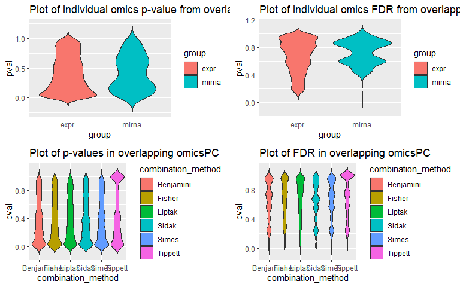

```r
#Nominal p-values plot individual omics
data_plot <- data.frame(pval=c(res$expr[,"Pr(>|z|)"],res$mirna[,"Pr(>|z|)"]),
                        group=c(rep(names(res)[1], nrow(res$expr)),
                                rep(names(res)[2], nrow(res$mirna))))

p1 <- ggplot(data_plot, aes(x=group, y=pval, fill=group)) +
  geom_violin(trim=FALSE)+
  labs(title='Plot of individual omics p-value from overlapping samples')

#FDR plot individual omics
data_plot <- data.frame(pval=c(res$expr[,"adj.P.Val"],res$mirna[,"adj.P.Val"]),
                        group=c(rep(names(res)[1], nrow(res$expr)),
                                rep(names(res)[2], nrow(res$mirna))))

p2 <- ggplot(data_plot, aes(x=group, y=pval, fill=group)) +
  geom_violin(trim=FALSE)+
  labs(title='Plot of individual omics FDR from overlapping samples')


#Nominal p-value plot PC
data_plot <- data.frame(pval=unlist(res$pvaluesPC[,-c(1,2)]),
                        combination_method=rep(colnames(res$pvaluesPC[,-c(1,2)]),
                                               each=nrow(res$pvaluesPC)))

p3 <- ggplot(data_plot, aes(x=combination_method, y=pval,
                            fill=combination_method)) +
  geom_violin(trim=FALSE)+
  labs(title='Plot of p-values in overlapping omicsPC')


#FDR plot PC
data_plot <- data.frame(pval=unlist(res$qvaluesPC[,-c(1,2)]),
                        combination_method=rep(colnames(res$qvaluesPC[,-c(1,2)]),
                                               each=nrow(res$qvaluesPC)))

p4 <- ggplot(data_plot, aes(x=combination_method, y=pval,
                            fill=combination_method)) +
  geom_violin(trim=FALSE)+
  labs(title='Plot of FDR in overlapping omicsPC')


grid.arrange(p1, p2, p3, p4, ncol=2, nrow=2)
```

Now, based on FDR results we can check if there is an increase of statistical power when both omics are jointly analyzed.

Note: here we consider significant an FDR<0.05.

```r
#significant genes
(sig_expr_cPC <- rownames(res$expr)[which(res$expr[,"adj.P.Val"]<0.05)])
```

```
## [1] "FAM46A"
```

```r
# 1 genes

#significant miRNA
(sig_mirna_cPC <- rownames(res$mirna)[which(res$mirna[,"adj.P.Val"]<0.05)])
```

```
## [1] "hsa-miR-222-3p"
```

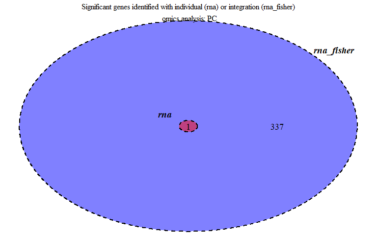

```r
# 1 miRNA

#Significant genes from mRNA + miRNA parametric combination (Fisher, FDR<0.05)
sig_expr_mirna_cPC <- res$qvaluesPC[which(res$qvaluesPC$Fisher<0.05),1:2]
#397 pairs

#venn diagram
m1 <- list(rna=sig_expr_cPC, rna_fisher=unique(sig_expr_mirna_cPC$expr))

vennPlot1 <- venn.diagram(m1, NULL, fill=c('red','blue'),
                         cat.fontface=4, lty=2, cex=1.2, cat.cex=1.2,
                         main='Significant genes identified with individual (rna) or integration (rna_fisher)\n omics analysis: PC')
grid.newpage()
grid.draw(vennPlot1)
```

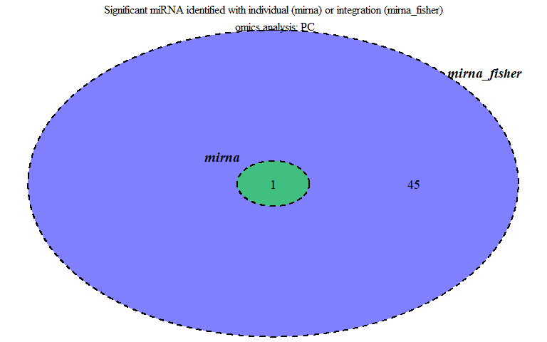

```r
m2 <- list(mirna=sig_mirna_cPC, mirna_fisher=unique(sig_expr_mirna_cPC$mirna))

vennPlot2 <- venn.diagram(m2, NULL, fill=c('green','blue'),
                         cat.fontface=4, lty=2, cex=1.2, cat.cex=1.2,
                         main='Significant miRNA identified with individual (mirna) or integration (mirna_fisher)\n omics analysis: PC')
grid.newpage()
grid.draw(vennPlot2)
```

When we perform the combination analysis we identify 337 new genes related with GBM survival and 45 miRNAs.

Here we can see the list of some of the new genes (n=337) identified based on Fisher combination.

```r
setdiff(sig_expr_mirna_cPC$expr,sig_expr_cPC)[1:50]
```

```
##  [1] "ACACA"    "ACSL3"    "ACTB"     "ACTG1"    "AHSA1"    "ALG3"
##  [7] "AMELX"    "ANXA2"    "AP1B1"    "AP3B1"    "APLP2"    "APOBEC3C"
## [13] "APOL2"    "APP"      "ARL4C"    "ATF5"     "ATP11B"   "ATP1A1"
## [19] "ATP2A2"   "ATP7B"    "AUTS2"    "BAG3"     "BBC3"     "BICD1"
## [25] "BPTF"     "C11orf57" "C8orf33"  "CABYR"    "CADM1"    "CANT1"
## [31] "CANX"     "CAPRIN1"  "CASC3"    "CASKIN2"  "CASP3"    "CAST"
## [37] "CBX2"     "CCDC47"   "CCR1"     "CCT3"     "CD44"     "CDKL5"
## [43] "CDKN1B"   "CDKN1C"   "CEBPB"    "CENPT"    "CEP250"   "CFLAR"
## [49] "CHL1"     "CKAP2"
```

And the new miRNAs (n=45) identified based on Fisher combination.

```r
setdiff(sig_expr_mirna_cPC$mirna,sig_mirna_cPC)
```

```
##  [1] "hsa-miR-221-3p"  "hsa-miR-148a-3p" "hsa-miR-155-5p"  "hsa-miR-132-3p"
##  [5] "hsa-miR-7-5p"    "hsa-miR-92a-3p"  "hsa-miR-26a-5p"  "hsa-miR-192-5p"
##  [9] "hsa-miR-18a-3p"  "hsa-miR-21-5p"   "hsa-miR-34a-5p"  "hsa-miR-31-5p"
## [13] "hsa-miR-124-3p"  "hsa-miR-335-5p"  "hsa-miR-181a-5p" "hsa-miR-27a-3p"
## [17] "hsa-miR-27b-3p"  "hsa-miR-346"     "hsa-miR-128-3p"  "hsa-miR-218-5p"
## [21] "hsa-miR-484"     "hsa-miR-9-5p"    "hsa-miR-19b-3p"  "hsa-miR-16-5p"
## [25] "hsa-miR-143-3p"  "hsa-miR-26b-5p"  "hsa-miR-378a-3p" "hsa-miR-215-5p"
## [29] "hsa-miR-25-3p"   "hsa-miR-98-5p"   "hsa-miR-30a-5p"  "hsa-miR-129-5p"
## [33] "hsa-miR-1"       "hsa-miR-199a-3p" "hsa-miR-145-5p"  "hsa-miR-200b-3p"
## [37] "hsa-miR-671-5p"  "hsa-miR-596"     "hsa-miR-93-5p"   "hsa-let-7e-5p"
## [41] "hsa-miR-203a"    "hsa-miR-196a-5p" "hsa-miR-299-5p"  "hsa-miR-331-3p"
## [45] "hsa-miR-197-3p"
```

##### 2.7.1.2.2 Non Parametric Combination

```r
set.seed(12345)

# Setting methods to combine pvalues
combMethods <- c("Fisher", "Liptak", "Tippett")
# Setting number of permutations
numPerms <- 1000
# Setting number of cores
numCores <- 4
# Setting omicsNPC to print out the steps that it performs.
verbose <- TRUE

omicsNPCRes_cNPC_rna_mirna <- omicsNPC(dataInput = dataInputExprMirna,
                         dataMapping = dataMappingExprMirna,
                         dataTypes = dataTypesExprMirna,
                         combMethods = combMethods,
                         numPerms = numPerms,
                         numCores = numCores,
                         verbose = verbose)
```

The output of `omicsNPC` provides information regarding p-value and adjusted p-value from both individual and combined analysis.

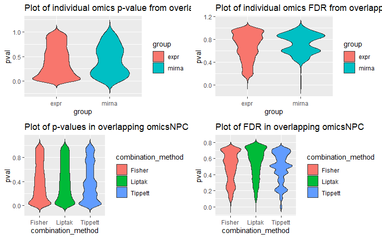

```r
res <- omicsNPCRes_cNPC_rna_mirna

#Nominal p-values plot individual omics
data_plot <- data.frame(pval=c(res$expr[,"Pr(>|z|)"],res$mirna[,"Pr(>|z|)"]),
                        group=c(rep(names(res)[1], nrow(res$expr)),
                                rep(names(res)[2], nrow(res$mirna))))

p1 <- ggplot(data_plot, aes(x=group, y=pval, fill=group)) +
  geom_violin(trim=FALSE)+
  labs(title='Plot of individual omics p-value from overlapping samples')

#FDR plot individual omics
data_plot <- data.frame(pval=c(res$expr[,"adj.P.Val"],res$mirna[,"adj.P.Val"]),
                        group=c(rep(names(res)[1], nrow(res$expr)),
                                rep(names(res)[2], nrow(res$mirna))))

p2 <- ggplot(data_plot, aes(x=group, y=pval, fill=group)) +
  geom_violin(trim=FALSE)+
  labs(title='Plot of individual omics FDR from overlapping samples')


#Nominal p-value plot NPC
data_plot <- data.frame(pval=unlist(res$pvaluesNPC[,-c(1:4)]),
                        combination_method=rep(colnames(res$pvaluesNPC[,-c(1:4)])
                                               , each=nrow(res$pvaluesNPC)))

p3 <- ggplot(data_plot, aes(x=combination_method, y=pval, fill=combination_method)) +
  geom_violin(trim=FALSE)+
  labs(title='Plot of p-values in overlapping omicsNPC')


#FDR plot NPC
data_plot <- data.frame(pval=unlist(res$qvaluesNPC[,-c(1:4)]),
                        combination_method=rep(colnames(res$qvaluesNPC[,-c(1:4)])
                                               , each=nrow(res$qvaluesNPC)))

p4 <- ggplot(data_plot, aes(x=combination_method, y=pval,
                            fill=combination_method)) +
  geom_violin(trim=FALSE)+
  labs(title='Plot of FDR in overlapping omicsNPC')


grid.arrange(p1, p2, p3, p4, ncol=2, nrow=2)
```

Now, based on FDR results we can check if there is an increase of statistical power when both omics are jointly analyzed.

Note: here we consider significant an FDR<0.05.

```r
#Significant genes or miRNA from individual omics (FDR<0.05)

#significant genes
(sig_expr_cNPC <- rownames(res$expr)[which(res$expr[,"adj.P.Val"]<0.05)])
```

```
## [1] "FAM46A"
```

```r
# 1 genes

#significant miRNA
(sig_mirna_cNPC <- rownames(res$mirna)[which(res$mirna[,"adj.P.Val"]<0.05)])
```

```
## [1] "hsa-miR-222-3p"
```

```r
# 1 miRNA

#Significant genes from mRNA + miRNA non parametric combination (Fisher, FDR<0.05)
(sig_expr_mirna_cNPC <- res$qvaluesNPC[which(res$qvaluesNPC[,'Fisher']<0.05),1:2])
```

```
##           expr          mirna
## 2961      CAST hsa-miR-222-3p
## 4533    CORO1A hsa-miR-222-3p
## 4535    CORO1A hsa-miR-221-3p
## 7198    FAM46A hsa-miR-34a-5p
## 7199    FAM46A  hsa-miR-21-5p
## 8004     GANAB hsa-miR-222-3p
## 8175      GDI2 hsa-miR-222-3p
## 8300      GLO1 hsa-miR-222-3p
## 8663     GRB10 hsa-miR-222-3p
## 9307  HIST3H2A hsa-miR-34a-5p
## 9864     ICAM1 hsa-miR-221-3p
## 9870     ICAM1 hsa-miR-222-3p
## 11406 LGALS3BP hsa-miR-222-3p
## 11423   LHFPL2 hsa-miR-221-3p
## 11790      LYN hsa-miR-222-3p
## 11841     MAFG hsa-miR-218-5p
## 11894    MAP1B hsa-miR-222-3p
## 12570   MGAT4B hsa-miR-222-3p
## 13368     NAIP hsa-miR-221-3p
## 14202    NSUN5 hsa-miR-222-3p
## 15529     PKP2 hsa-miR-222-3p
## 17947    RNF10 hsa-miR-222-3p
## 20848   STAT5A hsa-miR-222-3p
## 21240   TATDN2 hsa-miR-222-3p
## 21980    TMEM2  hsa-miR-21-5p
## 22130    TNIP1 hsa-miR-221-3p
## 22530   TRIM44 hsa-miR-222-3p
```

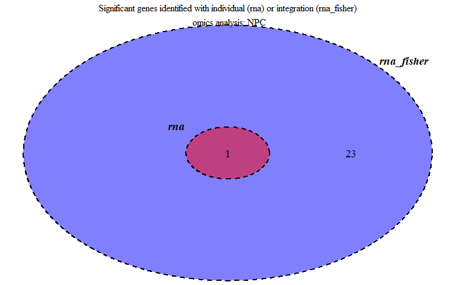

```r
# 27 pairs

#venn diagram
m1 <- list(rna=sig_expr_cNPC, rna_fisher=unique(sig_expr_mirna_cNPC$expr))

vennPlot1 <- venn.diagram(m1, NULL, fill=c('red','blue'),
                         cat.fontface=4, lty=2, cex=1.2, cat.cex=1.2, main='Significant genes identified with individual (rna) or integration (rna_fisher)\n omics analysis: NPC')
grid.newpage()
grid.draw(vennPlot1)
```

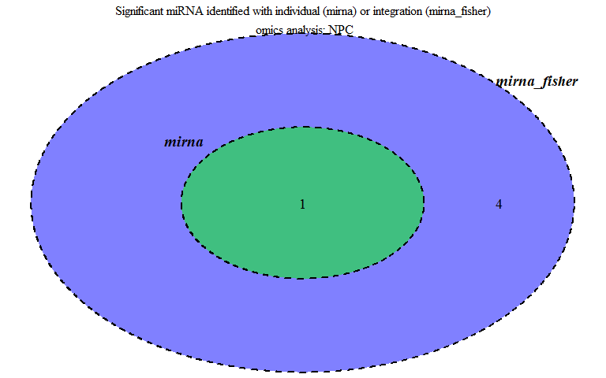

```r
m2 <- list(mirna=sig_mirna_cNPC, mirna_fisher=unique(sig_expr_mirna_cNPC$mirna))

vennPlot2 <- venn.diagram(m2, NULL, fill=c('green','blue'),
                         cat.fontface=4, lty=2, cex=1.2, cat.cex=1.2, main='Significant miRNA identified with individual (mirna) or integration (mirna_fisher)\n omics analysis: NPC')
grid.newpage()
grid.draw(vennPlot2)
```

Here we can see part of the list of new genes identified based on Fisher combination.

```r
setdiff(sig_expr_mirna_cNPC$expr,sig_expr_cNPC)
```

```
##  [1] "CAST"     "CORO1A"   "GANAB"    "GDI2"     "GLO1"     "GRB10"
##  [7] "HIST3H2A" "ICAM1"    "LGALS3BP" "LHFPL2"   "LYN"      "MAFG"
## [13] "MAP1B"    "MGAT4B"   "NAIP"     "NSUN5"    "PKP2"     "RNF10"
## [19] "STAT5A"   "TATDN2"   "TMEM2"    "TNIP1"    "TRIM44"
```

And the 4 new miRNA identified based on Fisher combination.

```r
setdiff(sig_expr_mirna_cNPC$mirna,sig_mirna_cNPC)
```

```
## [1] "hsa-miR-221-3p" "hsa-miR-34a-5p" "hsa-miR-21-5p"  "hsa-miR-218-5p"
```

#### 2.7.1.3 All samples

```r
#restrict the datasets to the elements of the data mapping
exprTMP <- rna_gbm_corrected[unique(na.omit(dataMappingExprMirna$expr)),]; #7,814 x 523

mirnaTMP <- new_mirna_matrix[unique(na.omit(dataMappingExprMirna$mirna)),]; #323 x 518

#specifying the data types.
dataTypesExprMirna <-  list(ttCoxphContinuous,ttCoxphContinuous)

#preparing the datasets
exprTMP <- createOmicsExpressionSet(Data = as.matrix(exprTMP),
                                    pData = clinical_gbm[colnames(rna_gbm_corrected),clinicalVariables[['expr']]])
names(pData(exprTMP)) <- c("age","outcome")

mirnaTMP <- createOmicsExpressionSet(Data = as.matrix(mirnaTMP),
                                     pData = clinical_gbm[colnames(mirna_gbm_corrected),clinicalVariables[['mirna']]])
names(pData(mirnaTMP)) <- c("age","outcome")

dataInputExprMirna <- list(expr = exprTMP, mirna = mirnaTMP)
```

##### 2.7.1.3.1 Parametric Combination

```r
set.seed(12345)
omicsPCRes_aPC <- omicsPC(dataInput = dataInputExprMirna,
                       dataMapping = dataMappingExprMirna,
                       dataTypes = dataTypesExprMirna,
                       verbose = TRUE)
```

The output of `omicsPC` provides information regarding p-value and adjusted p-value from both individual and combined analysis.

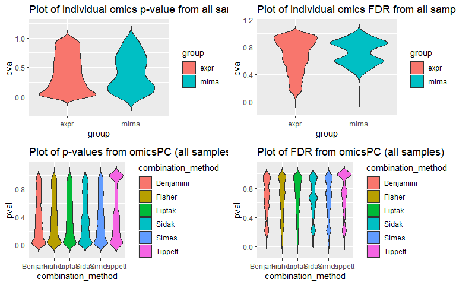

```r
res <- omicsPCRes_aPC

#Nominal p-values plot individual omics
data_plot <- data.frame(pval=c(res$expr[,"Pr(>|z|)"],res$mirna[,"Pr(>|z|)"]),
                        group=c(rep(names(res)[1], nrow(res$expr)),
                                rep(names(res)[2], nrow(res$mirna))))

p1 <- ggplot(data_plot, aes(x=group, y=pval, fill=group)) +
  geom_violin(trim=FALSE)+
  labs(title='Plot of individual omics p-value from all samples')

#FDR plot individual omics
data_plot <- data.frame(pval=c(res$expr[,"adj.P.Val"],res$mirna[,"adj.P.Val"]),
                        group=c(rep(names(res)[1], nrow(res$expr)),
                                rep(names(res)[2], nrow(res$mirna))))

p2 <- ggplot(data_plot, aes(x=group, y=pval, fill=group)) +
  geom_violin(trim=FALSE)+
  labs(title='Plot of individual omics FDR from all samples')


#Nominal p-value plot PC
data_plot <- data.frame(pval=unlist(res$pvaluesPC[,-c(1,2)]),
                        combination_method=rep(colnames(res$pvaluesPC[,-c(1,2)]),
                                               each=nrow(res$pvaluesPC)))

p3 <- ggplot(data_plot, aes(x=combination_method, y=pval,
                            fill=combination_method)) +
  geom_violin(trim=FALSE)+
  labs(title='Plot of p-values from omicsPC (all samples)')


#FDR plot PC
data_plot <- data.frame(pval=unlist(res$qvaluesPC[,-c(1,2)]),
                        combination_method=rep(colnames(res$qvaluesPC[,-c(1,2)]),
                                               each=nrow(res$qvaluesPC)))

p4 <- ggplot(data_plot, aes(x=combination_method, y=pval,
                            fill=combination_method)) +
  geom_violin(trim=FALSE)+
  labs(title='Plot of FDR from omicsPC (all samples)')


grid.arrange(p1, p2, p3, p4, ncol=2, nrow=2)
```

Now, based on FDR results we can check if there are an increase of statistical power when both omics are jointly analyzed.

Note: here we consider significant an FDR<0.05.

```r
#Significant genes or miRNA from individual omics (FDR<0.05)

#significant genes
(sig_expr_aPC <- rownames(res$expr)[which(res$expr[,"adj.P.Val"]<0.05)])
```

```
## [1] "FAM46A" "FUT4"   "FZD7"   "SNX10"
```

```r
# 4 genes

#significant miRNA
(sig_mirna_aPC <- rownames(res$mirna)[which(res$mirna[,"adj.P.Val"]<0.05)])
```

```
## [1] "hsa-miR-222-3p"
```

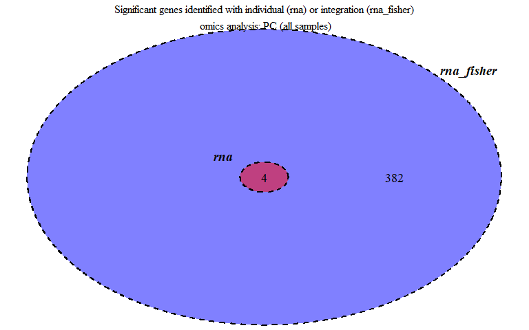

```r
# 1 miRNA

#Significant genes from mRNA + miRNA parametric combination (Fisher, FDR<0.05)
sig_expr_mirna_aPC <- res$qvaluesPC[which(res$qvaluesPC[,'Fisher']<0.05),1:2]
# 466 pairs

#venn diagram
m1 <- list(rna=sig_expr_aPC, rna_fisher=unique(sig_expr_mirna_aPC$expr))

vennPlot1 <- venn.diagram(m1, NULL, fill=c('red','blue'),
                         cat.fontface=4, lty=2, cex=1.2, cat.cex=1.2, main='Significant genes identified with individual (rna) or integration (rna_fisher)\n omics analysis: PC (all samples)')
grid.newpage()
grid.draw(vennPlot1)
```

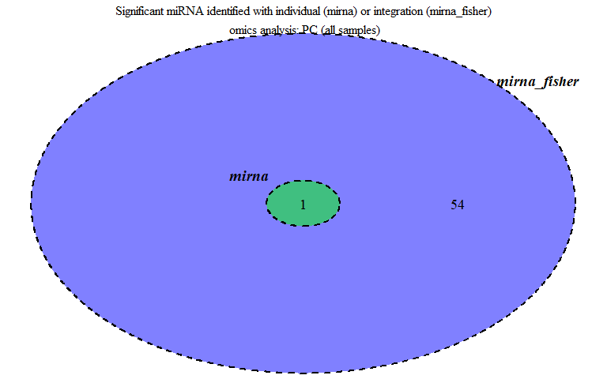

```r
m2 <- list(mirna=sig_mirna_aPC, mirna_fisher=unique(sig_expr_mirna_aPC$mirna))

vennPlot2 <- venn.diagram(m2, NULL, fill=c('green','blue'),
                         cat.fontface=4, lty=2, cex=1.2, cat.cex=1.2, main='Significant miRNA identified with individual (mirna) or integration (mirna_fisher)\n omics analysis: PC (all samples)')
grid.newpage()
grid.draw(vennPlot2)
```

When we perform the combination analysis we identify 382 new genes related with GBM survival and 54 miRNAs.

Here we can see part of the list of new genes (n=382) identified based on Fisher combination.

```r
setdiff(sig_expr_mirna_aPC$expr,sig_expr_aPC)[1:50]
```

```
##  [1] "ABHD3"    "ACACA"    "ACSL3"    "ACTB"     "ACTG1"    "AHSA1"
##  [7] "ALG3"     "AMELX"    "AMOT"     "ANXA2"    "AP1B1"    "AP3B1"
## [13] "APLP2"    "APOBEC3C" "APOL2"    "APP"      "ARL4C"    "ATF5"
## [19] "ATP11B"   "ATP1A1"   "ATP2A2"   "ATP7B"    "AUTS2"    "BAG3"
## [25] "BBC3"     "BCL2L11"  "BICD1"    "BPTF"     "C11orf57" "C8orf33"
## [31] "CABYR"    "CANT1"    "CANX"     "CAPG"     "CAPRIN1"  "CASC3"
## [37] "CASKIN2"  "CASP3"    "CAST"     "CBX2"     "CCDC47"   "CCR1"
## [43] "CCT3"     "CD44"     "CDC25C"   "CDKL5"    "CDKN1B"   "CDKN1C"
## [49] "CEBPB"    "CENPT"
```

And the new miRNAs (n=54) identified based on Fisher combination.

```r
setdiff(sig_expr_mirna_aPC$mirna,sig_mirna_aPC)
```

```
##  [1] "hsa-miR-221-3p"  "hsa-miR-148a-3p" "hsa-miR-155-5p"  "hsa-miR-132-3p"
##  [5] "hsa-miR-7-5p"    "hsa-miR-92a-3p"  "hsa-miR-26a-5p"  "hsa-miR-192-5p"
##  [9] "hsa-miR-18a-3p"  "hsa-miR-34a-5p"  "hsa-miR-21-5p"   "hsa-miR-31-5p"
## [13] "hsa-miR-124-3p"  "hsa-miR-335-5p"  "hsa-miR-181a-5p" "hsa-miR-27a-3p"
## [17] "hsa-miR-27b-3p"  "hsa-miR-346"     "hsa-miR-128-3p"  "hsa-miR-204-5p"
## [21] "hsa-miR-20b-5p"  "hsa-miR-218-5p"  "hsa-miR-215-5p"  "hsa-miR-484"
## [25] "hsa-miR-9-5p"    "hsa-miR-19b-3p"  "hsa-miR-331-3p"  "hsa-miR-16-5p"
## [29] "hsa-miR-143-3p"  "hsa-miR-26b-5p"  "hsa-miR-378a-3p" "hsa-miR-25-3p"
## [33] "hsa-miR-98-5p"   "hsa-miR-30a-5p"  "hsa-miR-129-5p"  "hsa-miR-1"
## [37] "hsa-miR-199a-3p" "hsa-miR-145-5p"  "hsa-miR-200b-3p" "hsa-miR-122-5p"
## [41] "hsa-miR-126-3p"  "hsa-miR-671-5p"  "hsa-miR-596"     "hsa-miR-93-5p"
## [45] "hsa-let-7e-5p"   "hsa-let-7a-5p"   "hsa-miR-32-5p"   "hsa-miR-375"
## [49] "hsa-miR-203a"    "hsa-miR-769-3p"  "hsa-miR-196a-5p" "hsa-miR-299-5p"
## [53] "hsa-miR-146a-5p" "hsa-miR-197-3p"
```

##### 2.7.1.3.2 Non Parametric Combination

```r
set.seed(12345)

# Setting methods to combine pvalues
combMethods <- c("Fisher", "Liptak", "Tippett")
# Setting number of permutations
numPerms <- 1000
# Setting number of cores
numCores <- 4
# Setting omicsNPC to print out the steps that it performs.
verbose <- TRUE

omicsNPCRes_aNPC_rna_mirna <- omicsNPC(dataInput = dataInputExprMirna,
                         dataMapping = dataMappingExprMirna,
                         dataTypes = dataTypesExprMirna,
                         combMethods = combMethods,
                         numPerms = numPerms,
                         numCores = numCores,
                         verbose = verbose)
```

The output of `omicsNPC` provides information regarding p-value and adjusted p-value from both individual and combined analysis.

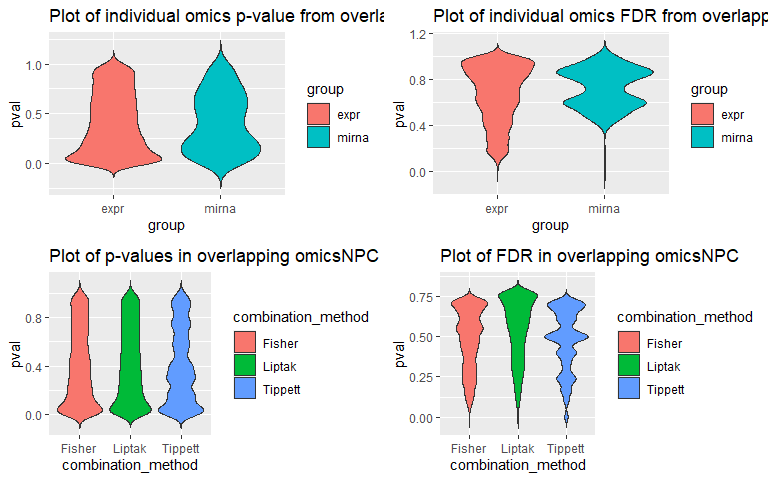

```r
res <- omicsNPCRes_aNPC_rna_mirna

#Nominal p-values plot individual omics
data_plot <- data.frame(pval=c(res$expr[,"Pr(>|z|)"],res$mirna[,"Pr(>|z|)"]),
                        group=c(rep(names(res)[1], nrow(res$expr)),
                                rep(names(res)[2], nrow(res$mirna))))

p1 <- ggplot(data_plot, aes(x=group, y=pval, fill=group)) +
  geom_violin(trim=FALSE)+
  labs(title='Plot of individual omics p-value from overlapping samples')

#FDR plot individual omics
data_plot <- data.frame(pval=c(res$expr[,"adj.P.Val"],res$mirna[,"adj.P.Val"]),
                        group=c(rep(names(res)[1], nrow(res$expr)),
                                rep(names(res)[2], nrow(res$mirna))))

p2 <- ggplot(data_plot, aes(x=group, y=pval, fill=group)) +
  geom_violin(trim=FALSE)+
  labs(title='Plot of individual omics FDR from overlapping samples')


#Nominal p-value plot NPC
data_plot <- data.frame(pval=unlist(res$pvaluesNPC[,-c(1:4)]),
                        combination_method=rep(colnames(res$pvaluesNPC[,-c(1:4)])
                                               , each=nrow(res$pvaluesNPC)))

p3 <- ggplot(data_plot, aes(x=combination_method, y=pval,
                            fill=combination_method)) +
  geom_violin(trim=FALSE)+
  labs(title='Plot of p-values in overlapping omicsNPC')


#FDR plot PC
data_plot <- data.frame(pval=unlist(res$qvaluesNPC[,-c(1:4)]),
                        combination_method=rep(colnames(res$qvaluesNPC[,-c(1:4)])
                                               , each=nrow(res$qvaluesNPC)))

p4 <- ggplot(data_plot, aes(x=combination_method, y=pval, fill=combination_method)) +
  geom_violin(trim=FALSE)+
  labs(title='Plot of FDR in overlapping omicsNPC')


grid.arrange(p1, p2, p3, p4, ncol=2, nrow=2)
```

Now, based on FDR results we can check if there are an increase of statistical power when both omics are jointly analyzed.

Note: here we consider significant an FDR<0.05.

```r
#Significant genes or miRNA from individual omics (FDR<0.05)

#significant genes
(sig_expr_aNPC <- rownames(res$expr)[which(res$expr[,"adj.P.Val"]<0.05)])
```

```
## [1] "FAM46A" "FUT4"   "FZD7"   "SNX10"
```

```r
# 4 genes

#significant miRNA
(sig_mirna_aNPC <- rownames(res$mirna)[which(res$mirna[,"adj.P.Val"]<0.05)])
```

```
## [1] "hsa-miR-222-3p"
```

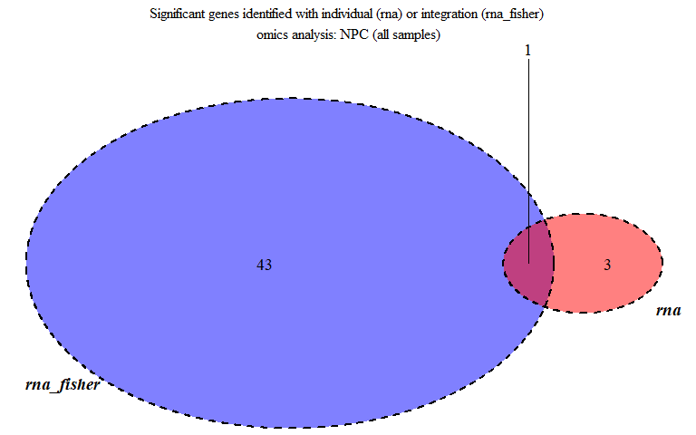

```r
# 1 miRNA

#Significant genes from mRNA + miRNA non parametric combination (Fisher, FDR<0.05)
sig_expr_mirna_aNPC <- res$qvaluesNPC[which(res$qvaluesNPC[,'Fisher']<0.05),1:2]
# 50 pairs

#venn diagram
m1 <- list(rna=sig_expr_aNPC, rna_fisher=unique(sig_expr_mirna_aNPC$expr))

vennPlot1 <- venn.diagram(m1, NULL, fill=c('red','blue'),
                         cat.fontface=4, lty=2, cex=1.2, cat.cex=1.2, main='Significant genes identified with individual (rna) or integration (rna_fisher)\n omics analysis: NPC (all samples)')
grid.newpage()
grid.draw(vennPlot1)
```

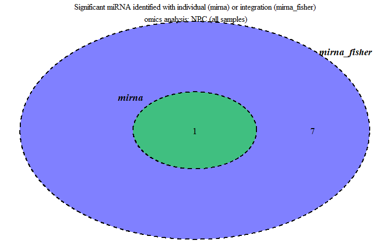

```r
m2 <- list(mirna=sig_mirna_aNPC, mirna_fisher=unique(sig_expr_mirna_aNPC$mirna))

vennPlot2 <- venn.diagram(m2, NULL, fill=c('green','blue'),
                         cat.fontface=4, lty=2, cex=1.2, cat.cex=1.2, main='Significant miRNA identified with individual (mirna) or integration (mirna_fisher)\n omics analysis: NPC (all samples)')
grid.newpage()
grid.draw(vennPlot2)
```

When we perform the combination analysis we identify 43 new genes related with GBM survival and 7 miRNAs.

Here we can see the list of new genes (n=43) identified based on Fisher combination.

```r
setdiff(sig_expr_mirna_aNPC$expr,sig_expr_aNPC)
```

```
##  [1] "ATF5"     "CAST"     "CLIC1"    "CORO1A"   "CUTA"     "EFNB2"
##  [7] "ENO1"     "EXOC3"    "FNDC3B"   "GANAB"    "GATA4"    "GDI2"
## [13] "GLO1"     "GRB10"    "HIST3H2A" "ICAM1"    "LGALS3BP" "LHFPL2"
## [19] "LRRFIP1"  "LYN"      "MAP1B"    "MET"      "MGAT4B"   "MYD88"
## [25] "MYO1C"    "NAIP"     "NSUN5"    "OLIG2"    "OSBPL10"  "PKP2"
## [31] "PRDM16"   "RNF10"    "SAP30L"   "SH3BGRL3" "STAT5A"   "TATDN2"
## [37] "TBK1"     "TMEM2"    "TNFSF10"  "TNIP1"    "TRIM44"   "TUB"
## [43] "ZIC3"
```

And the new miRNAs (n=7) identified based on Fisher combination.

```r
setdiff(sig_expr_mirna_aNPC$mirna,sig_mirna_aNPC)
```

```
## [1] "hsa-miR-221-3p"  "hsa-miR-155-5p"  "hsa-miR-218-5p"  "hsa-miR-34a-5p"
## [5] "hsa-miR-21-5p"   "hsa-miR-200b-3p" "hsa-miR-31-5p"
```

#### 2.7.1.4 Integration strategies comparison

Finally, we can compare the divergences between parametric and non-parametric approaches and between the overlapping or whole cohort escenarios.

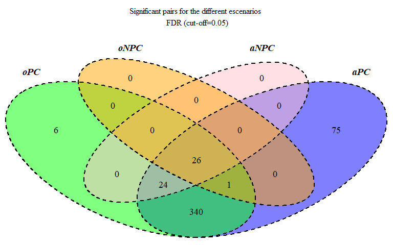

```r
#Significant pairs from different approaches

#parmetric combination with overlapping samples (n=397)
oPC <- paste(sig_expr_mirna_cPC$expr,sig_expr_mirna_cPC$mirna, sep=":")
#parmetric combination with all samples (n=466)
aPC <- paste(sig_expr_mirna_aPC$expr,sig_expr_mirna_aPC$mirna, sep=":")
#non parmetric combination with overlapping samples (n=27)
oNPC <- paste(sig_expr_mirna_cNPC$expr,sig_expr_mirna_cNPC$mirna, sep=":")
#non parmetric combination with all samples (n=50)
aNPC <- paste(sig_expr_mirna_aNPC$expr,sig_expr_mirna_aNPC$mirna, sep=":")

res_all <- list(oPC=oPC, aPC=aPC, oNPC=oNPC, aNPC=aNPC)

vennPlot_m1 <- venn.diagram(res_all, NULL, fill=c("green","blue","orange","pink"),
                            cat.fontface=4, lty=2, cex=1.2, cat.cex=1.2,
                            main="Significant pairs for the different escenarios \n FDR (cut-off=0.05)")

grid.newpage()
grid.draw(vennPlot_m1)
```

If we look in the significant pairs identified in each case (FDR<0.05), in total there are 472 pairs identified by the different approaches; being 5.5% (26/472) common between different methods. The use of whole data allows the identification of a largest number of signifcant pairs in both parametric and non parametric approach. Importantly, the main differences between identified pairs are found between parametric and non parametric approaches. PC approach identifies a large number of significant pairs in comparison to NPC approach.

### 2.7.2 mRNA + Methylation

First of all we need to have a mapping file mathcing omics.

#### 2.7.2.1 Mapping file

```r
#Load the mapping info
#load('methy2GeneMap.RData')
methy2GeneMap <- methy2GeneMap[-40902, ]; #repetition

#restricting mapping info to methylation info
methy2GeneMap_1 <- methy2GeneMap[methy2GeneMap[,1]%in%rownames(logit_met_gbm_corrected),] #from the initial 311,135 methyl features we get 57,645 in common

head(methy2GeneMap_1)
```

```
##          name   Gene
## 15 cg02725885 PPAP2C
## 16 cg09908879 PPAP2C
## 17 cg16691033 PPAP2C
## 18 cg02935627 PPAP2C
## 19 cg12272837 PPAP2C
## 20 cg25697727 PPAP2C
```

```r
#creating the mRNA association tables has been previously created
head(expr2GeneMap)
```

```
##   measurement    Gene
## 1       FSTL1   FSTL1
## 2        AACS    AACS
## 3       RPS11   RPS11
## 4     CREB3L1 CREB3L1
## 5       ELMO2   ELMO2
## 6       PNMA1   PNMA1
```

```r
#creating the data mapping (57,645 x 3)
dataMappingExprMet <- combiningMappings(mappings = list(expr = expr2GeneMap,
                                                        met = methy2GeneMap_1),
                                          retainAll = TRUE, reference = 'Gene');

head(dataMappingExprMet)
```

```
##     expr        met   Gene
## 2    A2M cg00134295    A2M
## 3 A4GALT cg01268859 A4GALT
## 4 A4GALT cg07393322 A4GALT
## 5 A4GALT cg26705472 A4GALT
## 6 A4GALT cg20706071 A4GALT
## 7  A4GNT cg23669440  A4GNT
```

We can see that based on our mRNA and methylation analysis, we have 57,645 pairs in total, it corresponds to 9,620 unique genes (80% from the whole mRNA dataset) and 57,645 unique methylation sites (18% from teh whole methylation dataset).

Then, we define the relevant clinical variables in each escenario. The variable of interest in the case of GBM is the `survivalOtucome`. Moreover, Moreover, `days_to_birth` is included as a confounder.

```r
clinicalVariables <- list(expr = c('days_to_birth', 'survivalOutcome'),
                          met = c('days_to_birth',
                                  'survivalOutcome'),
                          mirna = c('days_to_birth', 'survivalOutcome'));
```

#### 2.7.2.2 Overlaping samples

```r
#restrict the datasets to the elements of the data mapping
exprTMP <- rna_gbm_corrected[unique(na.omit(dataMappingExprMet$expr)),
                             ids_rna_met]
#Dimension: 9,620 x 83

metTMP <-logit_met_gbm_corrected[unique(na.omit(dataMappingExprMet$met)),
                                 ids_rna_met]
#Dimension: 57,645 x 83

#specifying the data types.
dataTypesExprMet <- list(ttCoxphContinuous,ttCoxphContinuous)

#preparing the datasets
exprTMP <- createOmicsExpressionSet(Data = as.matrix(exprTMP),
                                    pData = clinical_gbm[ids_rna_met,
                                                         clinicalVariables[['expr']]])
names(pData(exprTMP)) <- c("age","outcome")

metTMP <- createOmicsExpressionSet(Data = as.matrix(metTMP),
                                     pData = clinical_gbm[ids_rna_met,
                                                          clinicalVariables[['met']]])
names(pData(metTMP)) <- c("age","outcome")

dataInputExprMet <- list(expr = exprTMP, met = metTMP)
```

##### 2.7.2.2.1 Parametric Combination

```r
set.seed(12345)
omicsPCRes_cPC <- omicsPC(dataInput = dataInputExprMet,
                       dataMapping = dataMappingExprMet,
                       dataTypes = dataTypesExprMet,
                       verbose = TRUE)
```

The output of `omicsPC` provides information regarding p-value and adjusted p-value from both individual and combined analysis.

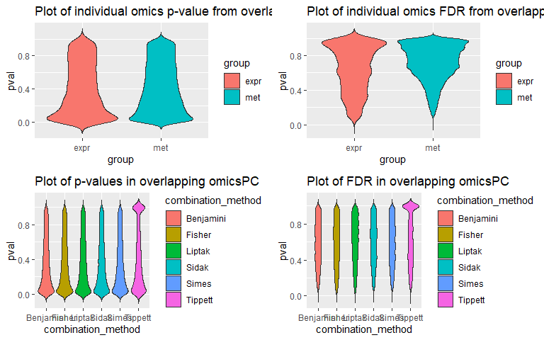

```r
res <- omicsPCRes_cPC

#Nominal p-values plot individual omics
data_plot <- data.frame(pval=c(res$expr[,"Pr(>|z|)"],res$met[,"Pr(>|z|)"]),
                        group=c(rep(names(res)[1], nrow(res$expr)),
                                rep(names(res)[2], nrow(res$met))))

p1 <- ggplot(data_plot, aes(x=group, y=pval, fill=group)) +
  geom_violin(trim=FALSE)+
  labs(title='Plot of individual omics p-value from overlapping samples')

#FDR plot individual omics
data_plot <- data.frame(pval=c(res$expr[,"adj.P.Val"],res$met[,"adj.P.Val"]),
                        group=c(rep(names(res)[1], nrow(res$expr)),
                                rep(names(res)[2], nrow(res$met))))

p2 <- ggplot(data_plot, aes(x=group, y=pval, fill=group)) +
  geom_violin(trim=FALSE)+
  labs(title='Plot of individual omics FDR from overlapping samples')


#Nominal p-value plot PC
data_plot <- data.frame(pval=unlist(res$pvaluesPC[,-c(1,2)]),
                        combination_method=rep(colnames(res$pvaluesPC[,-c(1,2)]),
                                               each=nrow(res$pvaluesPC)))

p3 <- ggplot(data_plot, aes(x=combination_method, y=pval,
                            fill=combination_method)) +
  geom_violin(trim=FALSE)+
  labs(title='Plot of p-values in overlapping omicsPC')


#FDR plot PC
data_plot <- data.frame(pval=unlist(res$qvaluesPC[,-c(1,2)]),
                        combination_method=rep(colnames(res$qvaluesPC[,-c(1,2)]),
                                               each=nrow(res$qvaluesPC)))

p4 <- ggplot(data_plot, aes(x=combination_method, y=pval,
                            fill=combination_method)) +
  geom_violin(trim=FALSE)+
  labs(title='Plot of FDR in overlapping omicsPC')


grid.arrange(p1, p2, p3, p4, ncol=2, nrow=2)
```

Now, based on FDR results we can check if there are an increase of statistical power when both omics are jointly analyzed.

Note: here we consider significant an FDR<0.05.

```r
#significant genes
(sig_expr_cPC <- rownames(res$expr)[which(res$expr[,"adj.P.Val"]<0.05)])
```

```
## [1] "CCDC41" "IGFBP6"
```

```r
# 2 genes

#significant methyl
(sig_met_cPC <- rownames(res$met)[which(res$met[,"adj.P.Val"]<0.05)])
```

```
## [1] "cg24113409"
```

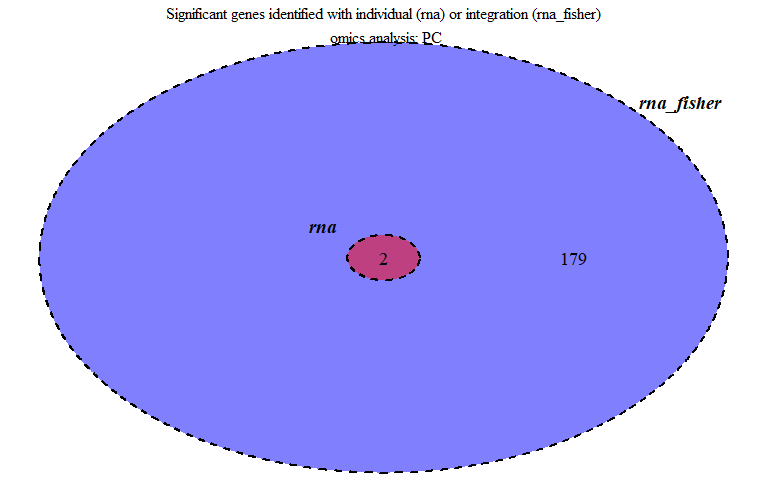

```r
# 1 methylation site

#Significant genes from mRNA + miRNA non parametric combination (Fisher, FDR<0.05)
sig_expr_met_cPC <- res$qvaluesPC[which(res$qvaluesPC[,'Fisher']<0.05),1:2]
#323 pairs

#venn diagram
m1 <- list(rna=sig_expr_cPC, rna_fisher=unique(sig_expr_met_cPC$expr))

vennPlot1 <- venn.diagram(m1, NULL, fill=c('red','blue'),
                         cat.fontface=4, lty=2, cex=1.2, cat.cex=1.2,
                         main='Significant genes identified with individual (rna) or integration (rna_fisher)\n omics analysis: PC')
grid.newpage()
grid.draw(vennPlot1)
```

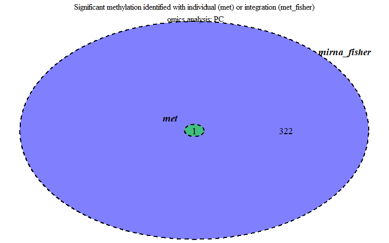

```r
m2 <- list(met=sig_met_cPC, mirna_fisher=unique(sig_expr_met_cPC$met))

vennPlot2 <- venn.diagram(m2, NULL, fill=c('green','blue'),
                         cat.fontface=4, lty=2, cex=1.2, cat.cex=1.2,
                         main='Significant methylation identified with individual (met) or integration (met_fisher)\n omics analysis: PC')
grid.newpage()
grid.draw(vennPlot2)
```

When we perform the combination analysis we identify 179 new genes related with GBM survival and 322 methylation sites.

Here we can see part of the new genes (n=179) identified based on Fisher combination.

```r
setdiff(sig_expr_met_cPC$expr,sig_expr_cPC)[1:50]
```

```
##  [1] "ABCG1"     "ADAM22"    "ADCYAP1R1" "ADORA3"    "AIM1L"     "AKAP1"
##  [7] "ALDH3B1"   "ALDH3B2"   "ALX1"      "AMPD3"     "ANGPTL4"   "ANK1"
## [13] "ANXA11"    "APOBEC3C"  "ARPC1B"    "ARSJ"      "AVPI1"     "B3GAT3"
## [19] "BANK1"     "BCAN"      "BCMO1"     "C1orf61"   "C20orf43"  "CAMTA2"
## [25] "CCR1"      "CDCP1"     "CDKN1A"    "CDYL"      "CEACAM4"   "CHMP6"
## [31] "CHN2"      "CLIP4"     "COL14A1"   "COL16A1"   "CPM"       "CREBBP"
## [37] "CREM"      "CRISPLD2"  "CSNK1D"    "CTSB"      "CXCR4"     "CYB5R2"
## [43] "DDR1"      "DENND2D"   "DLEU2"     "DSN1"      "DUS1L"     "DYNC2H1"
## [49] "ECHS1"     "EGR2"
```

And part of the new methylation sites (n=322) identified based on Fisher combination.

```r
setdiff(sig_expr_met_cPC$met,sig_met_cPC)[1:50]
```

```
##  [1] "cg01289965" "cg27220091" "cg27076139" "cg17617930" "cg05855208"
##  [6] "cg26915889" "cg12813724" "cg10667386" "cg05620821" "cg19933414"
## [11] "cg09982224" "cg15322932" "cg14871333" "cg24390938" "cg18229767"
## [16] "cg02494246" "cg20333014" "cg14996220" "cg12069276" "cg19132462"
## [21] "cg05647503" "cg18010131" "cg25968076" "cg07268332" "cg10811474"
## [26] "cg19585816" "cg04153489" "cg11647108" "cg06523744" "cg17140191"
## [31] "cg07634959" "cg12724221" "cg25217772" "cg05935311" "cg12664038"
## [36] "cg25217710" "cg19321979" "cg26781524" "cg26827725" "cg01518279"
## [41] "cg02232839" "cg14177914" "cg10945917" "cg26339180" "cg09578319"
## [46] "cg12509435" "cg05135942" "cg12762432" "cg17644311" "cg07118243"
```

##### 2.7.2.2.2 Non Parametric Combination

```r
set.seed(12345)

# Setting methods to combine pvalues
combMethods <- c("Fisher", "Liptak", "Tippett")
# Setting number of permutations
numPerms <- 1000
# Setting number of cores
numCores <- 1
# Setting omicsNPC to print out the steps that it performs.
verbose <- TRUE

omicsNPCRes_cNPC <- omicsNPC(dataInput = dataInputExprMet,
                         dataMapping = dataMappingExprMet,
                         dataTypes = dataTypesExprMet,
                         combMethods = combMethods,
                         numPerms = numPerms,
                         numCores = numCores,
                         verbose = verbose)
```

The output of `omicsNPC` provides information regarding p-value and adjusted p-value from both individual and combined analysis.

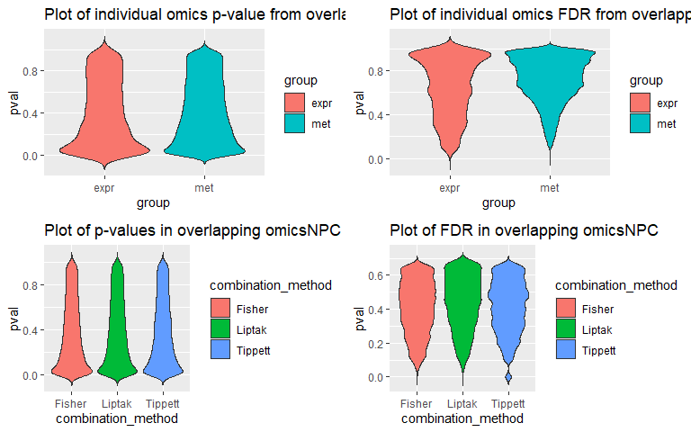

```r
res <- omicsNPCRes_cNPC_rna_met

#Nominal p-values plot individual omics
data_plot <- data.frame(pval=c(res$expr[,"Pr(>|z|)"],res$met[,"Pr(>|z|)"]),
                        group=c(rep(names(res)[1], nrow(res$expr)),
                                rep(names(res)[2], nrow(res$met))))

p1 <- ggplot(data_plot, aes(x=group, y=pval, fill=group)) +
  geom_violin(trim=FALSE)+
  labs(title='Plot of individual omics p-value from overlapping samples')

#FDR plot individual omics
data_plot <- data.frame(pval=c(res$expr[,"adj.P.Val"],res$met[,"adj.P.Val"]),
                        group=c(rep(names(res)[1], nrow(res$expr)),
                                rep(names(res)[2], nrow(res$met))))

p2 <- ggplot(data_plot, aes(x=group, y=pval, fill=group)) +
  geom_violin(trim=FALSE)+
  labs(title='Plot of individual omics FDR from overlapping samples')


#Nominal p-value plot NPC
data_plot <- data.frame(pval=unlist(res$pvaluesNPC[,-c(1:4)]),
                        combination_method=rep(colnames(res$pvaluesNPC[,-c(1:4)])
                                               , each=nrow(res$pvaluesNPC)))

p3 <- ggplot(data_plot, aes(x=combination_method, y=pval,
                            fill=combination_method)) +
  geom_violin(trim=FALSE)+
  labs(title='Plot of p-values in overlapping omicsNPC')


#FDR plot NPC
data_plot <- data.frame(pval=unlist(res$qvaluesNPC[,-c(1:4)]),
                        combination_method=rep(colnames(res$qvaluesNPC[,-c(1:4)])
                                               , each=nrow(res$qvaluesNPC)))

p4 <- ggplot(data_plot, aes(x=combination_method, y=pval,
                            fill=combination_method)) +
  geom_violin(trim=FALSE)+
  labs(title='Plot of FDR in overlapping omicsNPC')


grid.arrange(p1, p2, p3, p4, ncol=2, nrow=2)
```

Now, based on FDR results we can check if there are an increase of statistical power when both omics are jointly analyzed.

Note: here we consider significant an FDR<0.05.

```r
#Significant genes or miRNA from individual omics (FDR<0.05)

#significant genes
(sig_expr_cNPC <- rownames(res$expr)[which(res$expr[,"adj.P.Val"]<0.05)])
```

```
## [1] "CCDC41" "IGFBP6"
```

```r
# 2 genes

#significant met
(sig_met_cNPC <- rownames(res$met)[which(res$met[,"adj.P.Val"]<0.05)])
```

```
## [1] "cg24113409"
```

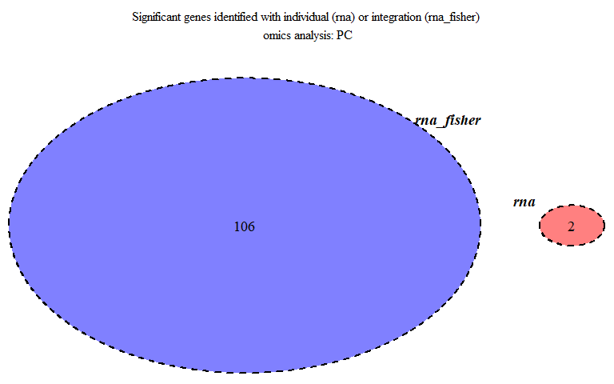

```r
# 1 methylation site

#Significant genes from mRNA + methylation non parametric combination (Fisher, FDR<0.05)
sig_expr_met_cNPC <- res$qvaluesNPC[which(res$qvaluesNPC[,'Fisher']<0.05),1:2]
# 150 pairs

#venn diagram
m1 <- list(rna=sig_expr_cNPC, rna_fisher=unique(sig_expr_met_cNPC$expr))

vennPlot1 <- venn.diagram(m1, NULL, fill=c('red','blue'),
                         cat.fontface=4, lty=2, cex=1.2, cat.cex=1.2,
                         main='Significant genes identified with individual (rna) or integration (rna_fisher)\n omics analysis: PC')
grid.newpage()
grid.draw(vennPlot1)
```

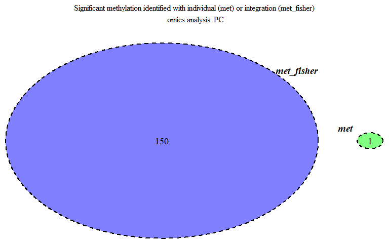

```r
m2 <- list(met=sig_met_cNPC, met_fisher=unique(sig_expr_met_cNPC$met))

vennPlot2 <- venn.diagram(m2, NULL, fill=c('green','blue'),
                         cat.fontface=4, lty=2, cex=1.2, cat.cex=1.2,
                         main='Significant methylation identified with individual (met) or integration (met_fisher)\n omics analysis: PC')
grid.newpage()
grid.draw(vennPlot2)
```

When we perform the combination analysis we identify 106 new genes related with GBM survival and 150 methylation sites.

Here we can see part of the new genes (n=106) identified based on Fisher combination.

```r
setdiff(sig_expr_met_cNPC$expr,sig_expr_cNPC)[1:50]
```

```
##  [1] "ABCG1"    "ADAM22"   "ADORA3"   "ALDH3B2"  "AMPD3"    "ANXA11"
##  [7] "APOBEC3C" "ARHGEF4"  "ARID5A"   "ARPC1B"   "AVPI1"    "BCAN"
## [13] "BCMO1"    "CCR1"     "CDCP1"    "CDKN1A"   "CDYL"     "CEACAM4"
## [19] "CHI3L1"   "CHMP6"    "CHST12"   "CPM"      "CYB5R2"   "DENND2D"
## [25] "EDNRB"    "EGR2"     "ELL2"     "ENOSF1"   "EPB41L3"  "EXPH5"
## [31] "FHL2"     "GAA"      "GCNT1"    "GPT"      "GRN"      "HCK"
## [37] "HK1"      "HLA-DMA"  "HOXA3"    "HPCAL1"   "HRAS"     "HTATIP2"
## [43] "ICAM1"    "IDH2"     "IFNGR2"   "IGFBP3"   "IL1RAP"   "IL4R"
## [49] "IL6R"     "ILF3"
```

And part of the new methylation sites (n=150) identified based on Fisher combination.

```r
setdiff(sig_expr_met_cNPC$met,sig_met_cNPC)[1:50]
```

```
##  [1] "cg01289965" "cg27220091" "cg26915889" "cg20333014" "cg12069276"
##  [6] "cg18010131" "cg25968076" "cg07268332" "cg11647108" "cg06523744"
## [11] "cg12910906" "cg16388829" "cg17140191" "cg12724221" "cg12664038"
## [16] "cg25217710" "cg19321979" "cg26781524" "cg11589536" "cg13722619"
## [21] "cg05389236" "cg24425727" "cg17526952" "cg24816460" "cg08249424"
## [26] "cg21529807" "cg05891548" "cg02097014" "cg00691948" "cg05483875"
## [31] "cg21211357" "cg21433768" "cg24575083" "cg16281276" "cg25722212"
## [36] "cg12847373" "cg20018723" "cg11571761" "cg20415170" "cg07100532"
## [41] "cg23564700" "cg16622495" "cg06550462" "cg12967001" "cg10022155"
## [46] "cg26344233" "cg01154930" "cg22289360" "cg26572973" "cg09957864"
```

#### 2.7.2.3 All samples

```r
#restrict the datasets to the elements of the data mapping
exprTMP <- rna_gbm_corrected[unique(na.omit(dataMappingExprMet$expr)),];
#Dimension: 9,620 x 523

metTMP <- logit_met_gbm_corrected[unique(na.omit(dataMappingExprMet$met)),];
#Dimension: 57,645 x 95

#specifying the data types.
dataTypesExprMet <- list(ttCoxphContinuous,ttCoxphContinuous)

#preparing the datasets
exprTMP <- createOmicsExpressionSet(Data = as.matrix(exprTMP),
                                    pData = clinical_gbm[colnames(rna_gbm_corrected),clinicalVariables[['expr']]])

names(pData(exprTMP)) <- c("age","outcome")

metTMP <- createOmicsExpressionSet(Data = as.matrix(metTMP),
                                     pData = clinical_gbm[colnames(logit_met_gbm_corrected),clinicalVariables[['met']]])

names(pData(metTMP)) <- c("age","outcome")

dataInputExprMet <- list(expr = exprTMP, met = metTMP)
```

##### 2.7.2.3.1 Parametric Combination

```r
set.seed(12345)
omicsPCRes_aPC <- omicsPC(dataInput = dataInputExprMet,
                       dataMapping = dataMappingExprMet,
                       dataTypes = dataTypesExprMet,
                       verbose = TRUE)
```

The output of `omicsPC` provides information regarding p-value and adjusted p-value from both individual and combined analysis.

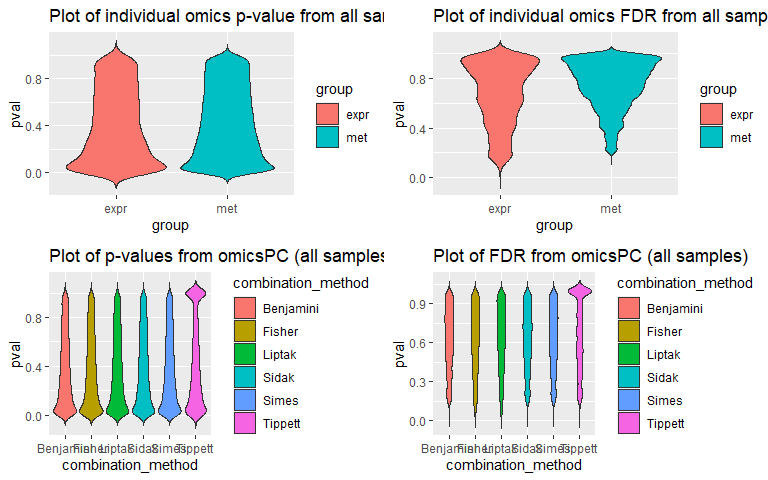

```r
res <- omicsPCRes_aPC

#Nominal p-values plot individual omics
data_plot <- data.frame(pval=c(res$expr[,"Pr(>|z|)"],res$met[,"Pr(>|z|)"]),
                        group=c(rep(names(res)[1], nrow(res$expr)),
                                rep(names(res)[2], nrow(res$met))))

p1 <- ggplot(data_plot, aes(x=group, y=pval, fill=group)) +
  geom_violin(trim=FALSE)+
  labs(title='Plot of individual omics p-value from all samples')

#FDR plot individual omics
data_plot <- data.frame(pval=c(res$expr[,"adj.P.Val"],res$met[,"adj.P.Val"]),
                        group=c(rep(names(res)[1], nrow(res$expr)),
                                rep(names(res)[2], nrow(res$met))))

p2 <- ggplot(data_plot, aes(x=group, y=pval, fill=group)) +
  geom_violin(trim=FALSE)+
  labs(title='Plot of individual omics FDR from all samples')


#Nominal p-value plot PC
data_plot <- data.frame(pval=unlist(res$pvaluesPC[,-c(1,2)]),
                        combination_method=rep(colnames(res$pvaluesPC[,-c(1,2)]),
                                               each=nrow(res$pvaluesPC)))

p3 <- ggplot(data_plot, aes(x=combination_method, y=pval,
                            fill=combination_method)) +
  geom_violin(trim=FALSE)+
  labs(title='Plot of p-values from omicsPC (all samples)')


#FDR plot PC
data_plot <- data.frame(pval=unlist(res$qvaluesPC[,-c(1,2)]),
                        combination_method=rep(colnames(res$qvaluesPC[,-c(1,2)]),
                                               each=nrow(res$qvaluesPC)))

p4 <- ggplot(data_plot, aes(x=combination_method, y=pval,
                            fill=combination_method)) +
  geom_violin(trim=FALSE)+
  labs(title='Plot of FDR from omicsPC (all samples)')


grid.arrange(p1, p2, p3, p4, ncol=2, nrow=2)
```

Now, based on FDR results we can check if there are an increase of statistical power when both omics are jointly analyzed.

Note: here we consider significant an FDR<0.05.

```r
#Significant genes or methylation from individual omics (FDR<0.05)

#significant genes
(sig_expr_aPC <- rownames(res$expr)[which(res$expr[,"adj.P.Val"]<0.05)])
```

```
## [1] "FAM46A"  "FNDC3B"  "FUT4"    "FZD7"    "PRM2"    "SIGLEC9" "SNX10"
```

```r
# 7 genes

#significant methylation sites
(sig_met_aPC <- rownames(res$met)[which(res$met[,"adj.P.Val"]<0.05)])
```

```
## character(0)
```

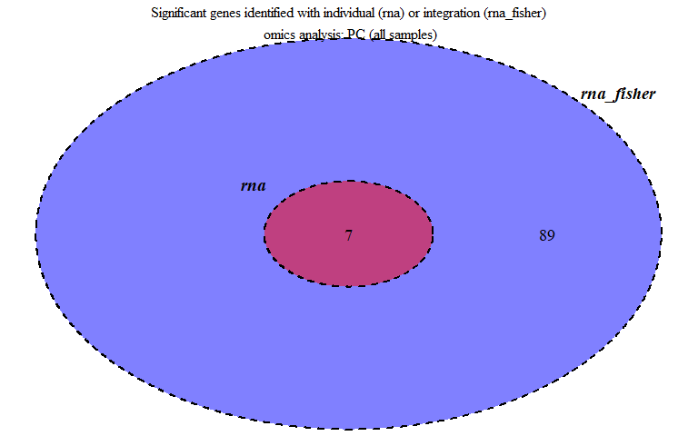

```r
# 0 methylation sites

#Significant genes from mRNA + methylation non parametric combination (Fisher, FDR<0.05)
sig_expr_met_aPC <- res$qvaluesPC[which(res$qvaluesPC[,'Fisher']<0.05),1:2]
# 207 pairs

#venn diagram
m1 <- list(rna=sig_expr_aPC, rna_fisher=unique(sig_expr_met_aPC$expr))

vennPlot1 <- venn.diagram(m1, NULL, fill=c('red','blue'),
                         cat.fontface=4, lty=2, cex=1.2, cat.cex=1.2, main='Significant genes identified with individual (rna) or integration (rna_fisher)\n omics analysis: PC (all samples)')
grid.newpage()
grid.draw(vennPlot1)
```

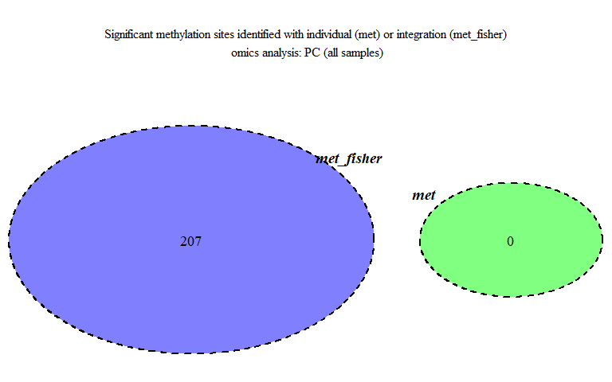

```r
m2 <- list(met=sig_met_aPC, met_fisher=unique(sig_expr_met_aPC$met))

vennPlot2 <- venn.diagram(m2, NULL, fill=c('green','blue'),
                         cat.fontface=4, lty=2, cex=1.2, cat.cex=1.2, main='Significant methylation sites identified with individual (met) or integration (met_fisher)\n omics analysis: PC (all samples)')
grid.newpage()
grid.draw(vennPlot2)
```

When we perform the combination analysis we identify 89 new genes related with GBM survival and 207 methylation sites.

Here we can see part of new genes (n=89) identified based on Fisher combination.

```r
setdiff(sig_expr_met_aPC$expr,sig_expr_aPC)
```

```
##  [1] "ALX1"     "AMPD3"    "ANXA11"   "APOBEC3C" "ARHGAP25" "ARPC1B"
##  [7] "ASCC1"    "ASCL2"    "ATP1A1"   "BICD1"    "BMP4"     "BRF1"
## [13] "BST2"     "BTNL2"    "C13orf15" "C2"       "C6orf48"  "CCR1"
## [19] "CHI3L1"   "CLIP4"    "CPD"      "CTSZ"     "CYB5R2"   "DENND2D"
## [25] "DGKZ"     "DKK3"     "DUS1L"    "DUSP5"    "EPB41L3"  "GCM2"
## [31] "GJA3"     "GRB10"    "HEXB"     "HIST3H2A" "HIVEP3"   "HOMER1"
## [37] "HPCAL1"   "HRAS"     "HS3ST3A1" "ICAM1"    "IFNGR2"   "IGFBP2"
## [43] "IGFBP3"   "IL17RA"   "LGALS3"   "LGALS3BP" "LGALS8"   "LHFPL2"
## [49] "LITAF"    "LRRK1"    "LZTS1"    "MKNK1"    "MLNR"     "MYD88"
## [55] "NCKAP1L"  "NDRG2"    "NFE2L3"   "NKX6-1"   "NUAK1"    "OSMR"
## [61] "PARVB"    "PAX9"     "PCSK1"    "PDGFA"    "PHF11"    "PLEKHG3"
## [67] "PLK2"     "PRKAG2"   "RAP2B"    "RGS16"    "ROBO4"    "SH2B3"
## [73] "SHANK1"   "SLC16A3"  "SLC20A1"  "SLC43A3"  "SOX1"     "SOX21"
## [79] "SREBF1"   "SV2B"     "TBX4"     "TCIRG1"   "TLR2"     "TLX3"
## [85] "TMEM2"    "TRPC6"    "UGP2"     "UPK2"     "ZNF208"
```

And the new methylation sites (n=207) identified based on Fisher combination (first 20 shown).

```r
setdiff(sig_expr_met_aPC$met,sig_met_aPC)[1:20]
```

```
##  [1] "cg14996220" "cg25800765" "cg19132462" "cg25968076" "cg11647108"
##  [6] "cg06523744" "cg15258980" "cg17140191" "cg19577016" "cg27252164"
## [11] "cg11342277" "cg15990192" "cg13079047" "cg21587861" "cg09229893"
## [16] "cg04269188" "cg16313343" "cg01254505" "cg17049418" "cg19281363"
```

##### 2.7.2.3.2 Non Parametric Combination

```r
set.seed(12345)

# Setting methods to combine pvalues
combMethods <- c("Fisher", "Liptak", "Tippett")
# Setting number of permutations
numPerms <- 1000
# Setting number of cores
numCores <- 4
# Setting omicsNPC to print out the steps that it performs.
verbose <- TRUE

omicsNPCRes_aNPC_rna_met <- omicsNPC(dataInput = dataInputExprMet,
                         dataMapping = dataMappingExprMet,
                         dataTypes = dataTypesExprMet,
                         combMethods = combMethods,
                         numPerms = numPerms,
                         numCores = numCores,
                         verbose = verbose)
```

The output of `omicsNPC` provides information regarding p-value and adjusted p-value from both individual and combined analysis.

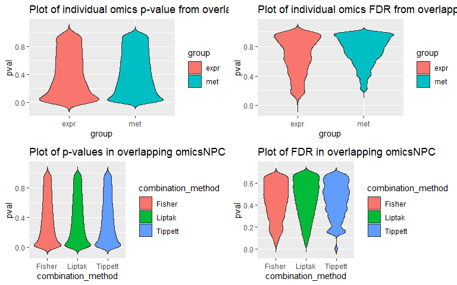

```r
res <- omicsNPCRes_aNPC_rna_met

#Nominal p-values plot individual omics
data_plot <- data.frame(pval=c(res$expr[,"Pr(>|z|)"],res$met[,"Pr(>|z|)"]),
                        group=c(rep(names(res)[1], nrow(res$expr)),
                                rep(names(res)[2], nrow(res$met))))

p1 <- ggplot(data_plot, aes(x=group, y=pval, fill=group)) +
  geom_violin(trim=FALSE)+
  labs(title='Plot of individual omics p-value from overlapping samples')

#FDR plot individual omics
data_plot <- data.frame(pval=c(res$expr[,"adj.P.Val"],res$met[,"adj.P.Val"]),
                        group=c(rep(names(res)[1], nrow(res$expr)),
                                rep(names(res)[2], nrow(res$met))))

p2 <- ggplot(data_plot, aes(x=group, y=pval, fill=group)) +
  geom_violin(trim=FALSE)+
  labs(title='Plot of individual omics FDR from overlapping samples')


#Nominal p-value plot NPC
data_plot <- data.frame(pval=unlist(res$pvaluesNPC[,-c(1:4)]),
                        combination_method=rep(colnames(res$pvaluesNPC[,-c(1:4)])
                                               , each=nrow(res$pvaluesNPC)))

p3 <- ggplot(data_plot, aes(x=combination_method, y=pval,
                            fill=combination_method)) +
  geom_violin(trim=FALSE)+
  labs(title='Plot of p-values in overlapping omicsNPC')


#FDR plot PC
data_plot <- data.frame(pval=unlist(res$qvaluesNPC[,-c(1:4)]),
                        combination_method=rep(colnames(res$qvaluesNPC[,-c(1:4)])
                                               , each=nrow(res$qvaluesNPC)))

p4 <- ggplot(data_plot, aes(x=combination_method, y=pval,
                            fill=combination_method)) +
  geom_violin(trim=FALSE)+
  labs(title='Plot of FDR in overlapping omicsNPC')


grid.arrange(p1, p2, p3, p4, ncol=2, nrow=2)
```

Now, based on FDR results we can check if there are an increase of statistical power when both omics are jointly analyzed.

Note: here we consider significant an FDR<0.05.

```r
#Significant genes or methylation sites from individual omics (FDR<0.05)

#significant genes
(sig_expr_aNPC <- rownames(res$expr)[which(res$expr[,"adj.P.Val"]<0.05)])
```

```
## [1] "FAM46A"  "FNDC3B"  "FUT4"    "FZD7"    "PRM2"    "SIGLEC9" "SNX10"
```

```r
#7 genes

#significant methylation sites
(sig_met_aNPC <- rownames(res$met)[which(res$met[,"adj.P.Val"]<0.05)])
```

```
## character(0)
```

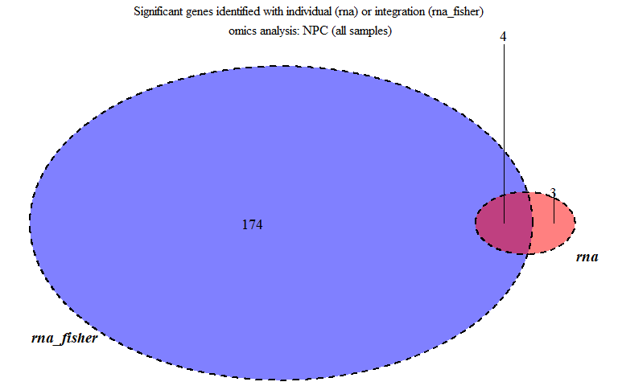

```r
#0 methylation sites

#Significant genes from mRNA + met non parametric combination (Fisher, FDR<0.05)
sig_expr_met_aNPC <- res$qvaluesNPC[which(res$qvaluesNPC[,'Fisher']<0.05),1:2]
# 332 pairs

#venn diagram
m1 <- list(rna=sig_expr_aNPC, rna_fisher=unique(sig_expr_met_aNPC$expr))

vennPlot1 <- venn.diagram(m1, NULL, fill=c('red','blue'),
                         cat.fontface=4, lty=2, cex=1.2, cat.cex=1.2, main='Significant genes identified with individual (rna) or integration (rna_fisher)\n omics analysis: NPC (all samples)')
grid.newpage()
grid.draw(vennPlot1)
```

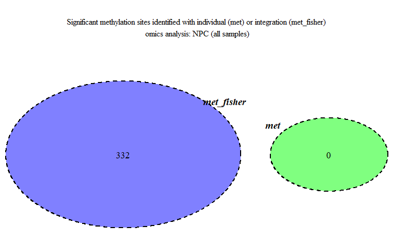

```r
m2 <- list(met=sig_met_aNPC, met_fisher=unique(sig_expr_met_aNPC$met))

vennPlot2 <- venn.diagram(m2, NULL, fill=c('green','blue'),
                         cat.fontface=4, lty=2, cex=1.2, cat.cex=1.2, main='Significant methylation sites identified with individual (met) or integration (met_fisher)\n omics analysis: NPC (all samples)')

grid.newpage()
grid.draw(vennPlot2)
```

When we perform the combination analysis we identify 174 genes related with GBM survival and 332 methylation site.

Here we can see a subset of the new genes (n=174) identified based on Fisher combination.

```r
setdiff(sig_expr_met_aNPC$expr,sig_expr_aNPC)[1:50]
```

```
##  [1] "ABCB9"    "ADK"      "AHNAK2"   "AIM1"     "ALX1"     "AMPD3"
##  [7] "ANXA11"   "APOBEC3C" "ARHGAP25" "ARPC1B"   "ASCC1"    "ASCL2"
## [13] "ASPSCR1"  "ATP1A1"   "ATP2A1"   "AVIL"     "B3GAT3"   "BCAN"
## [19] "BCL3"     "BMP4"     "BRF1"     "BST2"     "BTNL2"    "C13orf15"
## [25] "C2"       "C6orf48"  "CALCR"    "CAMTA2"   "CCR1"     "CDCP1"
## [31] "CDYL"     "CHI3L1"   "CHST2"    "COL16A1"  "CPD"      "CRHR2"
## [37] "CSNK1D"   "CTSZ"     "CUTA"     "CYB5R2"   "DENND2D"  "DGKZ"
## [43] "DKK3"     "DLC1"     "DUS1L"    "ECHDC2"   "EMILIN1"  "EPB41L3"
## [49] "ETFA"     "F3"
```

And the new methylation sites (n=332) identified based on Fisher combination.

```r
setdiff(sig_expr_met_aNPC$met,sig_met_aNPC)[1:50]
```

```
##  [1] "cg03328639" "cg16088251" "cg02719508" "cg23413349" "cg02409351"
##  [6] "cg14116122" "cg14996220" "cg25800765" "cg10794058" "cg19132462"
## [11] "cg18010131" "cg25968076" "cg11647108" "cg06523744" "cg15258980"
## [16] "cg17140191" "cg19577016" "cg27252164" "cg05309948" "cg04571951"
## [21] "cg21437208" "cg11342277" "cg15990192" "cg13079047" "cg10442913"
## [26] "cg00474713" "cg04046364" "cg25217772" "cg25217710" "cg17740327"
## [31] "cg09229893" "cg16389901" "cg04269188" "cg16313343" "cg01254505"
## [36] "cg17049418" "cg19281363" "cg00025981" "cg07249939" "cg12484688"
## [41] "cg14734916" "cg17243044" "cg13127825" "cg25110523" "cg06636203"
## [46] "cg25013586" "cg00058449" "cg06804823" "cg16617910" "cg09578319"
```

#### 2.7.2.4 Integration strategies comparison

Finally, we can compare the divergences between parametric and non-parametric approaches and the overlapping or whole cohort escenarios.

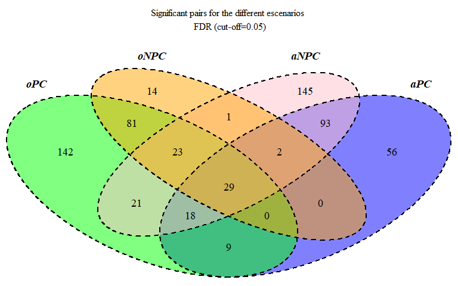

```r
#Significant pairs from different approaches

#parmetric combination with overlapping samples
oPC <- paste(sig_expr_met_cPC$expr,sig_expr_met_cPC$met, sep=":") #323
#parmetric combination with all samples
aPC <- paste(sig_expr_met_aPC$expr,sig_expr_met_aPC$met, sep=":") #207
#non parmetric combination with overlapping samples
oNPC <- paste(sig_expr_met_cNPC$expr,sig_expr_met_cNPC$met, sep=":") #150
#non parmetric combination with all samples
aNPC <- paste(sig_expr_met_aNPC$expr,sig_expr_met_aNPC$met, sep=":") #332

res_all <- list(oPC=oPC, aPC=aPC, oNPC=oNPC, aNPC=aNPC)

vennPlot_m1 <- venn.diagram(res_all, NULL, fill=c("green","blue","orange","pink"),
                            cat.fontface=4, lty=2, cex=1.2, cat.cex=1.2,
                          main="Significant pairs for the different escenarios \n FDR (cut-off=0.05)")

grid.newpage()
grid.draw(vennPlot_m1)
```

In this approach we can see that the results differ considerably depending on the type of approach used.